# Working with Data in the Tidyverse

Alison Hill - DataCamp

### Course Description

In this course, you’ll learn to work with data using tools from the tidyverse in R. By data, we mean your own data, other people’s data, messy data, big data, small data - any data with rows and columns that comes your way! By work, we mean doing most of the things that sound hard to do with R, and that need to happen before you can analyze or visualize your data. But work doesn’t mean that it is not fun - you will see why so many people love working in the tidyverse as you learn how to explore, tame, tidy, and transform your data. Throughout this course, you’ll work with data from a popular television baking competition called “The Great British Bake Off.”

# 1 Explore your data

You will start this course by learning how to read data into R. We’ll begin with the readr package, and use it to read in data files organized in rows and columns. In the rest of the chapter, you’ll learn how to explore your data using tools to help you view, summarize, and count values effectively. You’ll see how each of these steps gives you more insights into your data.

## 1.1 Import your data

### 1.1.1 Read a CSV file

In this exercise, you’ll use `read_csv()` twice. The first time you will only specify the filename, but you’ll notice a problem with the imported data. The second time you’ll use a new argument called `skip` to fix the problem. Remember to use `?read_csv` to read more about arguments like `skip` and how to use them.

The data you’ll work with is from “The Great British Bake-Off.” The file `“bakeoff.csv”` contains data for each episode of the show, organized by series and baker.

*This course touches on a lot of concepts you may have forgotten, so if you ever need a quick refresher, download the [Tidyverse Cheat Sheet](https://web.archive.org/web/20230309020541/https://datacamp-community-prod.s3.amazonaws.com/e63a8f6b-2aa3-4006-89e0-badc294b179c) and keep it handy!*

Load the `readr` package.

```r
# Load readr
library(readr)
```

- Use `read_csv()` to read in `“bakeoff.csv”`, and assign it to a new dataset `bakeoff` using the assignment operator (`<-`).

```r
# Create bakeoff from "bakeoff.csv"
bakeoff <- read_csv("https://assets.datacamp.com/production/repositories/1613/datasets/53cf6583aa659942b787897319a1ac053cbcfa5a/bakeoff.csv")
```

- Print `bakeoff` to view it. Look at the variable names and the first row of values. Do you notice any problems?

```r
# Print bakeoff
bakeoff
```

```
## # A tibble: 549 × 10
##    series episode baker     signature    technical showstopper result uk_airdate
##     <dbl>   <dbl> <chr>     <chr>            <dbl> <chr>       <chr>  <date>
##  1      1       1 Annetha   "Light Jama…         2 "Chocolate… IN     2010-08-17
##  2      1       1 David     "Chocolate …         3 "Black For… IN     2010-08-17
##  3      1       1 Edd       "Caramel Ci…         1  <NA>       IN     2010-08-17
##  4      1       1 Jasminder "Fresh Mang…        NA  <NA>       IN     2010-08-17
##  5      1       1 Jonathan  "Carrot Cak…         9 "Three-lay… IN     2010-08-17
##  6      1       1 Louise    "Carrot and…        NA "Never Fai… IN     2010-08-17
##  7      1       1 Miranda   "Triple Lay…         8 "Three Tie… IN     2010-08-17
##  8      1       1 Ruth      "Lemon Driz…        NA "Classic C… IN     2010-08-17
##  9      1       1 Lea       "Cranberry …        10 "Chocolate… OUT    2010-08-17
## 10      1       1 Mark      "Sticky Mar…        NA "Heart-sha… OUT    2010-08-17
## # … with 539 more rows, and 2 more variables: us_season <dbl>,
## #   us_airdate <date>
```

- Adapt your code to read in `“bakeoff.csv”` again, but this time, use the `skip` argument to skip the first line before reading the data. Print again to view it. Remember you can use `?read_csv`.

```r
# Create bakeoff but skip first row
bakeoff <- read_csv("https://assets.datacamp.com/production/repositories/1613/datasets/53cf6583aa659942b787897319a1ac053cbcfa5a/bakeoff.csv")
# Print bakeoff
bakeoff
```

```
## # A tibble: 549 × 10
##    series episode baker     signature    technical showstopper result uk_airdate
##     <dbl>   <dbl> <chr>     <chr>            <dbl> <chr>       <chr>  <date>
##  1      1       1 Annetha   "Light Jama…         2 "Chocolate… IN     2010-08-17
##  2      1       1 David     "Chocolate …         3 "Black For… IN     2010-08-17
##  3      1       1 Edd       "Caramel Ci…         1  <NA>       IN     2010-08-17
##  4      1       1 Jasminder "Fresh Mang…        NA  <NA>       IN     2010-08-17
##  5      1       1 Jonathan  "Carrot Cak…         9 "Three-lay… IN     2010-08-17
##  6      1       1 Louise    "Carrot and…        NA "Never Fai… IN     2010-08-17
##  7      1       1 Miranda   "Triple Lay…         8 "Three Tie… IN     2010-08-17
##  8      1       1 Ruth      "Lemon Driz…        NA "Classic C… IN     2010-08-17
##  9      1       1 Lea       "Cranberry …        10 "Chocolate… OUT    2010-08-17
## 10      1       1 Mark      "Sticky Mar…        NA "Heart-sha… OUT    2010-08-17
## # … with 539 more rows, and 2 more variables: us_season <dbl>,
## #   us_airdate <date>
```

### 1.1.2 Assign missing values

The `read_csv()` function also has an `na` argument, which allows you to specify value(s) that represent missing values in your data. The default values for the `na` argument are `c(““,”NA”)`, so both are recoded as missing (`NA`) in R. When you read in data, you can add additional values like the string **“UNKNOWN”** to a vector of missing values using the [`c()`](https://web.archive.org/web/20230309020541/https://www.rdocumentation.org/packages/base/versions/3.5.0/topics/c) function to combine multiple values into a single vector.

The [`is.na()`](https://web.archive.org/web/20230309020541/https://www.rdocumentation.org/packages/base/versions/3.5.1/topics/NA) function is also helpful for identifying rows with missing values for a variable.

- Load the `dplyr` package.

```r
# Load dplyr
library(dplyr)
```

- Add a `filter()` line after the pipe (`%>%`) to show only the rows in the `showstopper` variable coded as **“UNKNOWN”**.

```r
colnames(bakeoff)
```

```
##  [1] "series"      "episode"     "baker"       "signature"   "technical"
##  [6] "showstopper" "result"      "uk_airdate"  "us_season"   "us_airdate"
```

```r
# Filter rows where showstopper is UNKNOWN
bakeoff %>%
    filter(showstopper == "UNKNOWN")
```

```
## # A tibble: 0 × 10
## # … with 10 variables: series <dbl>, episode <dbl>, baker <chr>,
## #   signature <chr>, technical <dbl>, showstopper <chr>, result <chr>,
## #   uk_airdate <date>, us_season <dbl>, us_airdate <date>
```

- Adapt your code for creating `bakeoff` to add the `na` argument. Define `NA` values as a character string vector that includes the two default values (in the default order) *plus* **“UNKNOWN”**.

```r
# Edit to add list of missing values
bakeoff <- read_csv("https://assets.datacamp.com/production/repositories/1613/datasets/53cf6583aa659942b787897319a1ac053cbcfa5a/bakeoff.csv",
                    na = c("", "NA", "UNKNOWN"))
```

- Add a `filter()` line after the pipe (`%>%`) now to show rows where `showstopper` is missing, using the `is.na()` function.

```r
# Filter rows where showstopper is NA
bakeoff %>%
    filter(is.na(showstopper))
```

```
## # A tibble: 21 × 10
##    series episode baker     signature    technical showstopper result uk_airdate
##     <dbl>   <dbl> <chr>     <chr>            <dbl> <chr>       <chr>  <date>
##  1      1       1 Edd       "Caramel Ci…         1 <NA>        IN     2010-08-17
##  2      1       1 Jasminder "Fresh Mang…        NA <NA>        IN     2010-08-17
##  3      1       6 Miranda   "Lemon Cupc…        NA <NA>        RUNNE… 2010-09-21
##  4      2       1 Ian       "Apple and …        10 <NA>        IN     2011-08-16
##  5      2       1 Jason     "Lemon Meri…         6 <NA>        IN     2011-08-16
##  6      2       1 Urvashi   "Cherry Blo…         7 <NA>        IN     2011-08-16
##  7      2       1 Yasmin    "Cardamom a…         5 <NA>        IN     2011-08-16
##  8      2       1 Holly     "Cherry Bak…         1 <NA>        SB     2011-08-16
##  9      2       2 Ben       "Chorizo, P…         1 <NA>        IN     2011-08-23
## 10      2       2 Ian       "Stilton, S…         2 <NA>        IN     2011-08-23
## # … with 11 more rows, and 2 more variables: us_season <dbl>, us_airdate <date>
```

## 1.2 Know your data

### 1.2.1 Arrange and glimpse

From here, if we don’t ask you to load a package, you can assume it’s already loaded.

You can combine [`glimpse()`](https://web.archive.org/web/20230309020541/http://tibble.tidyverse.org/reference/glimpse.html) with other functions in a sequence using the pipe (`%>%`) operator. For example, you can use other `dplyr` functions like `arrange` first, then use `glimpse` by adding a line after the final pipe (`%>%`):

```
bakers_mini %>%
  arrange(age) %>%
  glimpse() # no argument needed here
```

Take a glimpse of the `bakeoff` data we imported in the first set of exercises. On which date did the first episode of the show air in the US?

*(Pressing `Enter` in the console will not add a new line, but will run the code on the current line. If you’d like to add a new line before running your code, you can use `Shift`+`Enter`)*

- `2010-08-17`

`2014-12-28`

- `2013-08-20`

Correct! The first episode of the first US season aired on December 28, 2014.

### 1.2.2 Summarize your data

You can combine [`skim()`](https://web.archive.org/web/20230309020541/https://www.rdocumentation.org/packages/skimr/versions/1.0.2/topics/skim) with other functions in a sequence using the pipe (`%>%`) operator. For example, you could use other `dplyr` functions like `group_by` first, then use `skim()` by adding a line after the final pipe.

```
bakers_mini %>%
  group_by(series) %>%
  skim() # no argument needed here
```

This will produce summary statistics for each `series`. Let’s practice this!

- Load the `skimr` package.

```r
# Load skimr
library(skimr)
```

- First `filter()` to extract only those observations where `us_season` is not missing, then pipe that to `skim()`. Recall that `!` means “not”, so `!is.na()` creates the right logical condition.

```r
# Filter and skim
bakeoff %>%
  filter(!is.na(us_season)) %>%
  skim()
```

Table 1.1: Data summary

| Name | Piped data |
| --- | --- |
| Number of rows | 302 |
| Number of columns | 10 |
| _______________________ |  |
| Column type frequency: |  |
| character | 4 |
| Date | 2 |
| numeric | 4 |
| ________________________ |  |
| Group variables | None |

**Variable type: character**

| skim_variable | n_missing | complete_rate | min | max | empty | n_unique | whitespace |
| --- | --- | --- | --- | --- | --- | --- | --- |
| baker | 0 | 1 | 3 | 9 | 0 | 48 | 0 |
| signature | 1 | 1 | 10 | 125 | 0 | 300 | 0 |
| showstopper | 1 | 1 | 5 | 126 | 0 | 298 | 0 |
| result | 0 | 1 | 2 | 9 | 0 | 6 | 0 |

**Variable type: Date**

| skim_variable | n_missing | complete_rate | min | max | median | n_unique |
| --- | --- | --- | --- | --- | --- | --- |
| uk_airdate | 0 | 1 | 2013-08-20 | 2016-10-26 | 2014-10-08 | 40 |
| us_airdate | 0 | 1 | 2014-12-28 | 2017-08-04 | 2015-11-08 | 35 |

**Variable type: numeric**

| skim_variable | n_missing | complete_rate | mean | sd | p0 | p25 | p50 | p75 | p100 | hist |
| --- | --- | --- | --- | --- | --- | --- | --- | --- | --- | --- |
| series | 0 | 1 | 5.49 | 1.13 | 4 | 4 | 5 | 6 | 7 | ▇▇▁▇▇ |
| episode | 0 | 1 | 4.37 | 2.66 | 1 | 2 | 4 | 6 | 10 | ▇▆▅▃▂ |
| technical | 1 | 1 | 4.85 | 2.98 | 1 | 2 | 4 | 7 | 13 | ▇▅▅▂▁ |
| us_season | 0 | 1 | 2.49 | 1.13 | 1 | 1 | 2 | 3 | 4 | ▇▇▁▇▇ |

- Add a line above the final `skim()` to group by `us_season` first, before getting the summary statistics.

```r
# Edit to filter, group by, and skim
bakeoff %>%
  filter(!is.na(us_season)) %>%
  group_by(us_season) %>%
  skim()
```

Table 1.2: Data summary

| Name | Piped data |
| --- | --- |
| Number of rows | 302 |
| Number of columns | 10 |
| _______________________ |  |
| Column type frequency: |  |
| character | 4 |
| Date | 2 |
| numeric | 3 |
| ________________________ |  |
| Group variables | us_season |

**Variable type: character**

| skim_variable | us_season | n_missing | complete_rate | min | max | empty | n_unique | whitespace |
| --- | --- | --- | --- | --- | --- | --- | --- | --- |
| baker | 1 | 0 | 1.00 | 3 | 9 | 0 | 13 | 0 |
| baker | 2 | 0 | 1.00 | 4 | 7 | 0 | 12 | 0 |
| baker | 3 | 0 | 1.00 | 3 | 6 | 0 | 12 | 0 |
| baker | 4 | 0 | 1.00 | 3 | 9 | 0 | 12 | 0 |
| signature | 1 | 0 | 1.00 | 10 | 125 | 0 | 78 | 0 |
| signature | 2 | 1 | 0.99 | 15 | 107 | 0 | 73 | 0 |
| signature | 3 | 0 | 1.00 | 12 | 64 | 0 | 74 | 0 |
| signature | 4 | 0 | 1.00 | 12 | 93 | 0 | 75 | 0 |
| showstopper | 1 | 0 | 1.00 | 5 | 126 | 0 | 78 | 0 |
| showstopper | 2 | 1 | 0.99 | 8 | 82 | 0 | 73 | 0 |
| showstopper | 3 | 0 | 1.00 | 10 | 70 | 0 | 73 | 0 |
| showstopper | 4 | 0 | 1.00 | 5 | 86 | 0 | 74 | 0 |
| result | 1 | 0 | 1.00 | 2 | 9 | 0 | 5 | 0 |
| result | 2 | 0 | 1.00 | 2 | 9 | 0 | 6 | 0 |
| result | 3 | 0 | 1.00 | 2 | 9 | 0 | 5 | 0 |
| result | 4 | 0 | 1.00 | 2 | 9 | 0 | 5 | 0 |

**Variable type: Date**

| skim_variable | us_season | n_missing | complete_rate | min | max | median | n_unique |
| --- | --- | --- | --- | --- | --- | --- | --- |
| uk_airdate | 1 | 0 | 1 | 2013-08-20 | 2013-10-22 | 2013-09-10 | 10 |
| uk_airdate | 2 | 0 | 1 | 2014-08-06 | 2014-10-08 | 2014-08-27 | 10 |
| uk_airdate | 3 | 0 | 1 | 2015-08-05 | 2015-10-07 | 2015-08-26 | 10 |
| uk_airdate | 4 | 0 | 1 | 2016-08-24 | 2016-10-26 | 2016-09-14 | 10 |
| us_airdate | 1 | 0 | 1 | 2014-12-28 | 2015-03-01 | 2015-01-18 | 10 |
| us_airdate | 2 | 0 | 1 | 2015-09-06 | 2015-11-08 | 2015-09-27 | 10 |
| us_airdate | 3 | 0 | 1 | 2016-07-01 | 2016-08-12 | 2016-07-15 | 7 |
| us_airdate | 4 | 0 | 1 | 2017-06-16 | 2017-08-04 | 2017-06-30 | 8 |

**Variable type: numeric**

| skim_variable | us_season | n_missing | complete_rate | mean | sd | p0 | p25 | p50 | p75 | p100 | hist |
| --- | --- | --- | --- | --- | --- | --- | --- | --- | --- | --- | --- |
| series | 1 | 0 | 1.00 | 4.00 | 0.00 | 4 | 4.00 | 4.0 | 4 | 4 | ▁▁▇▁▁ |
| series | 2 | 0 | 1.00 | 5.00 | 0.00 | 5 | 5.00 | 5.0 | 5 | 5 | ▁▁▇▁▁ |
| series | 3 | 0 | 1.00 | 6.00 | 0.00 | 6 | 6.00 | 6.0 | 6 | 6 | ▁▁▇▁▁ |
| series | 4 | 0 | 1.00 | 7.00 | 0.00 | 7 | 7.00 | 7.0 | 7 | 7 | ▁▁▇▁▁ |
| episode | 1 | 0 | 1.00 | 4.31 | 2.66 | 1 | 2.00 | 4.0 | 6 | 10 | ▇▆▅▃▂ |
| episode | 2 | 0 | 1.00 | 4.38 | 2.68 | 1 | 2.00 | 4.0 | 6 | 10 | ▇▆▅▃▂ |
| episode | 3 | 0 | 1.00 | 4.40 | 2.67 | 1 | 2.00 | 4.0 | 6 | 10 | ▇▆▅▃▂ |
| episode | 4 | 0 | 1.00 | 4.40 | 2.67 | 1 | 2.00 | 4.0 | 6 | 10 | ▇▆▅▃▂ |
| technical | 1 | 0 | 1.00 | 5.08 | 3.19 | 1 | 2.25 | 4.5 | 7 | 13 | ▇▅▅▂▂ |
| technical | 2 | 1 | 0.99 | 4.73 | 2.93 | 1 | 2.00 | 4.0 | 7 | 12 | ▇▅▃▂▂ |
| technical | 3 | 0 | 1.00 | 4.80 | 2.92 | 1 | 2.00 | 4.0 | 7 | 12 | ▇▅▃▂▂ |
| technical | 4 | 0 | 1.00 | 4.80 | 2.92 | 1 | 2.00 | 4.0 | 7 | 12 | ▇▅▃▂▂ |

Nice piping & skimming! Producing quick grouped summaries with the `skim` function is a real time (and sanity) saver.

### 1.2.3 Know your variable types

How many variables of each type do we have in the `bakeoff` data? You may use any of the data science tools we’ve learned for getting to know your data (`dplyr` and `skimr` are loaded for you). You may also want to try piping a skimmed object to `summary()`, also from the `skimr` package:

```
tibble_name %>%
  skim() %>%  # no argument needed here
  summary() # no argument needed here
```

*(Pressing `Enter` in the console will not add a new line, but will run the code on the current line. If you’d like to add a new line before running your code, you can use `Shift`+`Enter`)*

Date: 2, character: 3, factor: 1, integer: 4

- Date: 3, character: 3, factor: 1, integer: 3
- Date: 2, character: 3, factor: 1, integer: 3

Correct!

## 1.3 Count with your data

### 1.3.1 Distinct and count

In every episode of “The Great British Bake-Off”, bakers complete 3 challenges and the show’s judges award the title “Star Baker” to the baker who excelled in that week’s challenges (with the exception of the finale). Each baker’s result for every episode is stored in `bakeoff`- `result` is a character variable, and the value “SB” stands for star baker.

View the distinct values for the `result` variable. Is “SB” one of them?

```r
# View distinct results
bakeoff %>%
  distinct(result)
```

```
## # A tibble: 6 × 1
##   result
##   <chr>
## 1 IN
## 2 OUT
## 3 RUNNER UP
## 4 WINNER
## 5 SB
## 6 LEFT
```

Adapt your code to `count` rows by `result` instead. How many star bakers are there?

```r
# Count rows for each result
bakeoff %>%
  count(result)
```

```
## # A tibble: 6 × 2
##   result        n
##   <chr>     <int>
## 1 IN          393
## 2 LEFT          1
## 3 OUT          70
## 4 RUNNER UP    16
## 5 SB           61
## 6 WINNER        8
```

Adapt your code to `count` by a logical condition instead: if the `result` is equal to `“SB”`.

```r
# Count whether or not star baker
bakeoff %>%
  count(result == "SB")
```

```
## # A tibble: 2 × 2
##   `result == "SB"`     n
##   <lgl>            <int>
## 1 FALSE              488
## 2 TRUE                61
```

Nice logical detective work! There are 488 results that are not star baker.

### 1.3.2 Count episodes

In the video, here’s how we used `count()` back-to-back to roll up a level of detail across `series`:

```
bakers %>%
  count(aired_us, series) %>%
  count(aired_us)
```

```
# A tibble: 2 x 2
  aired_us    nn
  <lgl>    <int>
1 FALSE        4
2 TRUE         4
```

Recall that `bakeoff` includes each baker’s result for every episode. Let’s practice counting the number of episodes per series.

Add a line after the pipe (%>%) to count rows by series and episode.

```r
# Count the number of rows by series and episode
bakeoff %>%
  count(series, episode)
```

```
## # A tibble: 74 × 3
##    series episode     n
##     <dbl>   <dbl> <int>
##  1      1       1    10
##  2      1       2     8
##  3      1       3     6
##  4      1       4     5
##  5      1       5     4
##  6      1       6     3
##  7      2       1    12
##  8      2       2    11
##  9      2       3    10
## 10      2       4     8
## # … with 64 more rows
```

- Adapt your code to add a second `count()` by series again to count the total number of episodes per series.

```r
# Add second count by series
bakeoff %>%
  count(series, episode) %>%
  count(series)
```

```
## # A tibble: 8 × 2
##   series     n
##    <dbl> <int>
## 1      1     6
## 2      2     8
## 3      3    10
## 4      4    10
## 5      5    10
## 6      6    10
## 7      7    10
## 8      8    10
```

Great work- you can see that by series 3 we were treated to 10 episodes with each new series!

### 1.3.3 Count bakers

In the last exercise, here’s how you used `count()` back-to-back to count episodes by series:

```
bakeoff %>%
  count(series, episode) %>%
  count(series)
```

```
# A tibble: 8 x 2
  series    nn
   <int> <int>
1      1     6
2      2     8
3      3    10
4      4    10
5      5    10
6      6    10
7      7    10
8      8    10
```

Now, using the same `bakeoff` data, you’ll practice that again, focusing on counting bakers.

- Create a new tibble by `count`ing rows by `series` and `baker`. Print your new counted tibble.

```r
# Count the number of rows by series and baker
bakers_by_series <- bakeoff %>%
  count(series, baker)

# Print to view
bakers_by_series
```

```
## # A tibble: 95 × 3
##    series baker         n
##     <dbl> <chr>     <int>
##  1      1 Annetha       2
##  2      1 David         4
##  3      1 Edd           6
##  4      1 Jasminder     5
##  5      1 Jonathan      3
##  6      1 Lea           1
##  7      1 Louise        2
##  8      1 Mark          1
##  9      1 Miranda       6
## 10      1 Ruth          6
## # … with 85 more rows
```

- Add a line to `count` the already counted tibble by `series` again. Which series had the most bakers? Which had the least?

```r
# Count again by series
bakers_by_series %>%
  count(series)
```

```
## # A tibble: 8 × 2
##   series     n
##    <dbl> <int>
## 1      1    10
## 2      2    12
## 3      3    12
## 4      4    13
## 5      5    12
## 6      6    12
## 7      7    12
## 8      8    12
```

- Now `count` the same tibble by `baker` again and use `sort = TRUE`. What’s the most common baker name?

```r
# Count again by baker
bakers_by_series %>%
  count(baker, sort = TRUE)
```

```
## # A tibble: 86 × 2
##    baker      n
##    <chr>  <int>
##  1 Kate       3
##  2 Ian        2
##  3 James      2
##  4 Louise     2
##  5 Mark       2
##  6 Peter      2
##  7 Robert     2
##  8 Tom        2
##  9 Ali        1
## 10 Alvin      1
## # … with 76 more rows
```

Good work- Series 4 had the most bakers with 13 total (a baker’s dozen!). Kate is the most popular name- Kates have appeared in 3 different series of the TV show.

### 1.3.4 Plot counts

You can learn a lot about your data by counting, but sometimes you can learn even more by plotting counts. This is especially true when you have lots of things to count! With eight series, 74 episodes, and 95 bakers, a plot can be more helpful than a table of numbers. We’ll use `ggplot2` (already loaded for you) to visualize the number of bakers across episodes for each series from `bakeoff`.

Make a bar chart using `geom_bar` to plot the number of bakers from `bakeoff` per `episode` along the x-axis. Use `facet_wrap` by `series`.

```r
library(tidyverse)
```

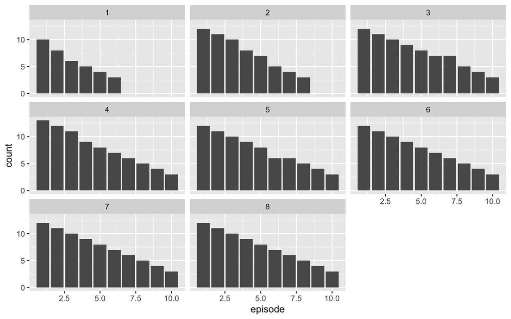

```r
ggplot(bakeoff, aes(episode)) +
    geom_bar() +
    facet_wrap(~series)
```

You made it through the first chapter! We have a lot of work left to do with The Great British Bake Off data, but notice how this plot is a great sanity check: the number of bakers tends to go down with every episode (never up!), with a few exceptions where no one was eliminated. Also, you can see that there are fewer episodes in the first two series. Finally, you can see that there are always three bakers who make it to the series finale.

# 2 Tame your data

In this chapter, you will learn some basics of data taming, like how to tame your variable types, names, and values.

## 2.1 Cast column types

### 2.1.1 Cast a column to a date

As we saw in the video, a good workflow for parsing dates using `readr` is to, for example:

- Use `parse_date(“2012-14-08”, format = “%Y-%d-%m”)` first, then
- Use `col_date(format = “%Y-%d-%m”)` within `cols()` as the `col_types` argument of `read_csv()`.

In `“desserts.csv”`, the variable `uk_airdate` is formatted like `“17 August 2010”`. Let’s parse, then cast this variable!

Later on in Chapter 4, we’ll showcase some functions from the `lubridate` package to help you extract data from dates, once they are cast properly.

Use `?parse_date` to find the right format to parse the date `“17 August 2010”`.

```r
# Find format to parse "17 August 2010"
parse_date("17 August 2010", format = "%d %B %Y")
```

```
## [1] "2010-08-17"
```

Cast the `uk_airdate` column as a date of the right format using the `col_date()` function with the `format` argument.

```r
# Edit to cast uk_airdate
desserts <- read_csv("https://raw.githubusercontent.com/ThanhDatIU/datacamp/main/desserts.csv",
                     col_types = cols(
                       uk_airdate = col_date(format = "%d %B %Y")
                     )
                    )
```

Sort `desserts` in descending order by `uk_airdate`. when did the last episode air in the UK?

```r
# Arrange by descending uk_airdate
desserts %>%
    arrange(desc(uk_airdate))
```

```
## # A tibble: 549 × 16
##    series episode baker  technical result    uk_airdate us_season us_airdate
##     <dbl>   <dbl> <chr>  <chr>     <chr>     <date>         <dbl> <date>
##  1      8      10 Kate   3rd       RUNNER UP 2017-10-31        NA NA
##  2      8      10 Steven 1st       RUNNER UP 2017-10-31        NA NA
##  3      8      10 Sophie 2nd       WINNER    2017-10-31        NA NA
##  4      8       9 Kate   4th       IN        2017-10-24        NA NA
##  5      8       9 Steven 3rd       IN        2017-10-24        NA NA
##  6      8       9 Stacey 2nd       OUT       2017-10-24        NA NA
##  7      8       9 Sophie 1st       SB        2017-10-24        NA NA
##  8      8       8 Kate   2nd       IN        2017-10-17        NA NA
##  9      8       8 Sophie 4th       IN        2017-10-17        NA NA
## 10      8       8 Steven 1st       IN        2017-10-17        NA NA
## # … with 539 more rows, and 8 more variables: showstopper_chocolate <chr>,
## #   showstopper_dessert <chr>, showstopper_fruit <chr>, showstopper_nut <chr>,
## #   signature_chocolate <chr>, signature_dessert <chr>, signature_fruit <chr>,
## #   signature_nut <chr>
```

Looking good! Notice that `us_airdate` didn’t need to be cast - this is because the date format `%Y-%m-%d` is unambiguous, so it is automatically parsed as a date by `readr`.

### 2.1.2 Cast a column to a number

In the video, we saw a good workflow for parsing columns using `readr`:

- Use `parse_number()` to practice, then
- Use `col_number()` to cast.

But sometimes you’ll need to start with casting, then diagnose parsing problems using a new `readr` function called [`problems()`](https://web.archive.org/web/20230309020541/https://www.rdocumentation.org/packages/readr/versions/1.1.1/topics/problems). Using `problems()` on a result of `read_csv()` will show you the rows and columns where parsing error occurred, what the parser expected to find (for example, a number), and the actual value that caused the parsing error.

Let’s practice this with `“desserts.csv”`, which includes data about the judges’ ranks for each baker in the `technical` challenge, for every episode.

Add another line to `cols()` to cast the `technical` column as a number. You will get a parsing error! Read the red text carefully.

```r
# Try to cast technical as a number
desserts <- read_csv("https://raw.githubusercontent.com/ThanhDatIU/datacamp/main/desserts.csv",
                     col_types = cols(
                       uk_airdate = col_date(format = "%d %B %Y"),
                       technical = col_number()
                     )
                    )
```

Pass the `desserts` tibble to the `problems()` function. Which values were not parsed (take a look at the `actual` column)?

```r
# View parsing problems
problems(desserts)
```

```
## # A tibble: 7 × 5
##     row   col expected actual file
##   <int> <int> <chr>    <chr>  <chr>
## 1     5     4 a number N/A    ""
## 2     7     4 a number N/A    ""
## 3     9     4 a number N/A    ""
## 4    11     4 a number N/A    ""
## 5    35     4 a number N/A    ""
## 6    36     4 a number N/A    ""
## 7    37     4 a number N/A    ""
```

Adapt the code so that the value that `read_csv()` couldn’t parse would instead be read as missing (think back to chapter 1!)

```r
# Edit code to fix the parsing error
desserts <- read_csv("https://raw.githubusercontent.com/ThanhDatIU/datacamp/main/desserts.csv",
                      col_types = cols(
                        uk_airdate = col_date(format = "%d %B %Y"),
                        technical = col_number()
                      ),
                        na = c("", "NA", "N/A")
                     )

# View parsing problems
problems(desserts)
```

```
## # A tibble: 0 × 5
## # … with 5 variables: row <int>, col <int>, expected <chr>, actual <chr>,
## #   file <chr>
```

Great work dealing with a tricky parsing problem!

### 2.1.3 Cast a column as a factor

Factors are categorical variables, where the possible values are a fixed and known set. For example, take a simple factor like `bake` below:

```
bake <- c("pie", "cake", "neither")
parse_factor(bake, levels = NULL)
```

```
[1] pie  cake neither
Levels: pie cake neither
```

You can use `parse_factor()` to parse variables and `col_factor()` to cast columns as categorical. Both functions have a `levels` argument that is used to specify the possible values for the factors. When `levels` is set to `NULL`, the possible values will be inferred from the unique values in the dataset. Alternatively, you can pass a list of possible values.

This is the last time you’ll read in `“desserts.csv”`! This time, you will look at the `result` column, which contains the outcome of the competition for each baker.

Adapt your code from the previous exercise to cast `result` as a factor; detect the factor levels based on the unique values present in each variable. Use `glimpse()` to check your work.

```r
# Cast result a factor
desserts <- read_csv("https://raw.githubusercontent.com/ThanhDatIU/datacamp/main/desserts_tidy.csv",
                     na = c("", "NA", "N/A"),
                     col_types = cols(
                       uk_airdate = col_date(format = "%d %B %Y"),
                       technical = col_number(),
                       result = col_factor(levels = NULL)
                     )
                    )

# Glimpse to view
glimpse(desserts)
```

```
## Rows: 1,098
## Columns: 14
## $ series     <dbl> 1, 1, 1, 1, 1, 1, 1, 1, 1, 1, 1, 1, 1, 1, 1, 1, 1, 1, 1, 1,…
## $ episode    <dbl> 1, 1, 1, 1, 1, 1, 1, 1, 1, 1, 2, 2, 2, 2, 2, 2, 2, 2, 3, 3,…
## $ baker      <chr> "Annetha", "David", "Edd", "Jasminder", "Jonathan", "Louise…
## $ technical  <dbl> 2, 3, 1, NA, 9, NA, 8, NA, 10, NA, 8, 6, 2, 1, 3, 5, 7, 4, …
## $ result     <fct> IN, IN, IN, IN, IN, IN, IN, IN, OUT, OUT, IN, IN, IN, IN, I…
## $ uk_airdate <date> 2010-08-17, 2010-08-17, 2010-08-17, 2010-08-17, 2010-08-17…
## $ us_season  <dbl> NA, NA, NA, NA, NA, NA, NA, NA, NA, NA, NA, NA, NA, NA, NA,…
## $ us_airdate <date> NA, NA, NA, NA, NA, NA, NA, NA, NA, NA, NA, NA, NA, NA, NA…
## $ challenge  <chr> "signature", "signature", "signature", "signature", "signat…
## $ bake       <chr> "light jamaican black cake\nwith strawberries and cream", "…
## $ dessert    <chr> "cake", "cake", "cake", "cake", "cake", "cake", "cake", "ca…
## $ chocolate  <chr> "no chocolate", "chocolate", "no chocolate", "no chocolate"…
## $ fruit      <chr> "no fruit", "fruit", "fruit", "fruit", "fruit", "fruit", "f…
## $ nut        <chr> "no nut", "no nut", "no nut", "no nut", "no nut", "no nut",…
```

You’ve casted like a champ! While it takes a lot of work up front, casting column types when you import can make your analyses easier to reproduce (for yourself too!).

## 2.2 Recode values

### 2.2.1 Recode a character variable

In this exercise, you’ll [`recode()`](https://web.archive.org/web/20230309020541/https://www.rdocumentation.org/packages/dplyr/versions/0.7.3/topics/recode) the `nut` variable in the `desserts` data. This is a character variable that tells us, for each bake, whether a nut was a key ingredient and if so, what kind of nut!

Remember that the arguments of `recode()` are the variable that you want to recode, and then an expression of the form `old_value = new_value`. `recode()` is most useful when used inside a `mutate()` to create a new variable or reassign the old one.

Often you want to recode a certain value as missing. In this case, it is important to preserve the data type of the variable. R has built-in words to indicate missing data of various types, for example `NA_character_` for missing value for a character variable, or `NA_integer_` for missing integer data. The `NA` value is of the logical type.

Remember that you can use `?function_name_here` to read more about arguments and how to use them.

- Count the distinct values in the `nut` variable, **sorting the result** based on the number of rows. How many bakes included filberts as the nut?

```r
# Count rows grouping by nut variable
desserts %>%
    count(nut, sort = TRUE)
```

```
## # A tibble: 8 × 2
##   nut           n
##   <chr>     <int>
## 1 no nut      944
## 2 almond       35
## 3 walnut       35
## 4 pistachio    29
## 5 filbert      23
## 6 pecan        14
## 7 multiple      9
## 8 peanut        9
```

- What is a `“filbert”`, you may ask? Recode `“filbert”` to `“hazelnut”`, store the result in the same `nut` column, and count again.

```r
# Recode filberts as hazelnuts
desserts_2 <- desserts %>%
  mutate(nut = recode(nut, "filbert" = "hazelnut"))

# Count rows again
desserts_2 %>%
    count(nut, sort = TRUE)
```

```
## # A tibble: 8 × 2
##   nut           n
##   <chr>     <int>
## 1 no nut      944
## 2 almond       35
## 3 walnut       35
## 4 pistachio    29
## 5 hazelnut     23
## 6 pecan        14
## 7 multiple      9
## 8 peanut        9
```

- Edit your code to also recode `“no nut”` as a missing *character* value, and count again to check your work.

```r
# Edit code to recode "no nut" as missing
desserts_2 <- desserts %>%
  mutate(nut = recode(nut, "filbert" = "hazelnut",
                           "no nut" = NA_character_))

# Count rows again
desserts_2 %>%
    count(nut, sort = TRUE)
```

```
## # A tibble: 8 × 2
##   nut           n
##   <chr>     <int>
## 1 <NA>        944
## 2 almond       35
## 3 walnut       35
## 4 pistachio    29
## 5 hazelnut     23
## 6 pecan        14
## 7 multiple      9
## 8 peanut        9
```

Nice! `NA` is a logical constant, so it is always helpful to remember the `NA` constants like `NA_character_` and `NA_integer_` when working with strings or numbers. Always know your variable types!

### 2.2.2 Recode a numeric variable

Dummy variables are often used in data analysis to bin a variable into one of two categories to indicate the absence or presence of something. Dummy variables take the value `0` or `1` to stand for, for example, loser or winner. Dummy variables are often *factor* variables as opposed to numeric - we’ll cover more about factors in the last chapter.

In `desserts`, the `technical` variable is a number representing the judges’ ranks for each baker in the technical challenge, for every episode (remember to run `glimpse(desserts)` to take a peek). In this exercise, you will recode the numeric `technical` variable to a new factor dummy variable.

- Create a new dummy variable called `tech_win`: it should be equal to `1` if the baker was ranked first in the technical challenge, and `0` if not. Remember that when recoding numeric variables, you need to put the *old* value in backticks, for example, `5 = 6`.

```r
# Create dummy variable: 1 if won, 0 if not
desserts <- desserts %>%
  mutate(tech_win = recode(technical, `1` = 1,
                           .default = 0))
```

- Use `count` to compare the number of rows where `technical` is equal to `1` versus all distinct values in the new `tech_win` variable.

```r
# Count to compare values
desserts %>%
  count(technical == 1, tech_win)
```

```
## # A tibble: 3 × 3
##   `technical == 1` tech_win     n
##   <lgl>               <dbl> <int>
## 1 FALSE                   0   936
## 2 TRUE                    1   146
## 3 NA                     NA    16
```

- You may have noticed that `tech_win` is a numeric variable (a `dbl`). Adapt your code to use [`recode_factor()`](https://web.archive.org/web/20230309020541/https://www.rdocumentation.org/packages/dplyr/versions/0.7.3/topics/recode) instead of `recode` to convert it to a factor.

```r
# Edit to recode tech_win as factor
desserts <- desserts %>%
  mutate(tech_win = recode_factor(technical, `1` = 1,
                                  .default = 0))

# Count to compare values
desserts %>%
  count(technical == 1, tech_win)
```

```
## # A tibble: 3 × 3
##   `technical == 1` tech_win     n
##   <lgl>            <fct>    <int>
## 1 FALSE            0          936
## 2 TRUE             1          146
## 3 NA               <NA>        16
```

Great job! We’ll do more complex recoding and learn more about factors in the last chapter- get excited!

## 2.3 Select variables

### 2.3.1 Combine functions with select

The `ratings` data tells us about how many UK viewers tuned in to watch “The Great British Bake-Off” for each episode of each series. If you explore `ratings` in console, you’ll see that there is a separate variable for the number of viewers for each episode. A key question we’ll return to in Chapter 3 is: how many more viewers watched the finale than the premiere episode?

Use the data science tools you’ve learned so far to answer:

> For series with 10 episodes, which showed the most growth in viewers from the premiere to the finale? Which showed the least?

*(Pressing `Enter` in the console will not add a new line, but will run the code on the current line. If you’d like to add a new line before running your code, you can use `Shift`+`Enter`)*

- Most: series 6, Least = series 7

Most: series 5, Least = series 8

- Most: series 8, Least = series 3
- Most: series 7, Least = series 5

Correct! Series 5 on BBC One showed the most, while series 8 on Channel 4 showed the least.

### 2.3.2 Recode factor to plot

In the last exercise, you may have used `mutate()` to find the difference between the number of premiere and finale episode viewers for each series. This variable, which I created and called `viewer_growth`, is now available in `ratings`, and feel free to check out it.

Now let’s practice using `select()` to check the result of another `mutate` with `recode_factor()`.

If you have examined `ratings`, you might have seen that series have aired on three different channels: “Channel 4”, “BBC One”, “BBC Two”.

- Create a new *factor* variable `bbc` by recoding `channel` with two levels using `recode_factor()`: `0` if that series aired on `“Channel 4”` and `1` if that series aired on any BBC station.

```r
ratings = read.csv("https://raw.githubusercontent.com/ThanhDatIU/datacamp/main/02.03_messy_ratings.csv")
# Recode channel as factor: "Channel 4" (0) or not (1)
ratings <- ratings %>%
  mutate(bbc = recode_factor(channel,
                             "Channel 4" = 0,
                             .default = 1))
```

Use `select()` to view the `series`, `channel`, `bbc`, and `viewer_growth` variables to check that your recoding worked.

```r
ratings <- ratings %>%
  filter(episodes == 10) %>%
  mutate(viewer_growth = e10_viewers_7day - e1_viewers_7day)
# Select to look at variables to plot next
ratings %>%
  select(series, channel, bbc, viewer_growth)
```

```
##   series   channel bbc viewer_growth
## 1      3   BBC Two   1          2.89
## 2      4   BBC Two   1          2.85
## 3      5   BBC One   1          5.00
## 4      6   BBC One   1          3.43
## 5      7   BBC One   1          2.32
## 6      8 Channel 4   0          0.58
```

Make a bar chart of `ratings` where the height of the bars shows `viewer_growth`, with `series` on the x-axis. Use `fill` and the newly created factor variable to color the bars according to whether it aired on a BBC channel to see when the show switched from the BBC.

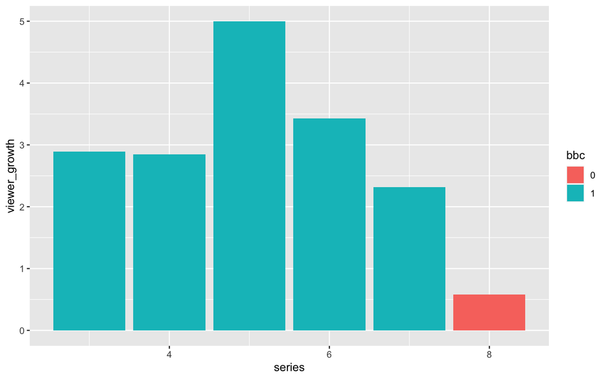

```r
# Make a filled bar chart
ggplot(ratings, aes(x = series, y = viewer_growth, fill = bbc)) +
  geom_col()
```

Good selections. Remember to look up the other select helper functions using `?select`. What is going on with `viewer_growth` in series 8? Stay tuned to find out!

### 2.3.3 Select and reorder variables

As we have seen, selecting a subset of columns to print can help you check that a `mutate()` worked as expected, and rearranging columns next to each other can help you spot obvious errors in data entry.

The [`select()` helpers](https://web.archive.org/web/20230309020541/https://www.rdocumentation.org/packages/tidyselect/versions/0.2.4/topics/select_helpers) are functions that you can use inside `select()` to allow you to select variables based on their names.

In this exercise, you’ll work with the `ratings` data, and you’ll use a new helper function called [`everything()`](https://web.archive.org/web/20230309020541/https://www.rdocumentation.org/packages/tidyselect/versions/0.2.4/topics/select_helpers) which can be useful when reordering columns. Use `?everything` to read more. You will learn more about using helper functions in the next lesson.

Use `select()` to move `channel` to the front of `ratings`, while also keeping *all* other variables using `everything()`.

```r
# Move channel to first column
ratings %>%
  select(channel, everything())
```

```
##     channel series episodes  premiere    finale            winner
## 1   BBC Two      3       10 14-Aug-12 16-Oct-12       John Whaite
## 2   BBC Two      4       10 20-Aug-13 22-Oct-13     Frances Quinn
## 3   BBC One      5       10  6-Aug-14  8-Oct-14 Nancy Birtwhistle
## 4   BBC One      6       10  5-Aug-15  7-Oct-15    Nadiya Hussain
## 5   BBC One      7       10 24-Aug-16 26-Oct-16     Candice Brown
## 6 Channel 4      8       10 29-Aug-17 31-Oct-17      Sophie Faldo
##   avg_uk_viewers day_of_week timeslot      runner_up_1          runner_up_2
## 1           5.00     Tuesday 20:00:00    Brendan Lynch         James Morton
## 2           7.35     Tuesday 20:00:00 Kimberley Wilson          Ruby Tandoh
## 3          10.04   Wednesday 20:00:00     Luis Troyano         Richard Burr
## 4          12.50   Wednesday 20:00:00      Ian Cumming            Tamal Ray
## 5          13.85   Wednesday 20:00:00     Andrew Smyth          Jane Beedle
## 6           9.29     Tuesday 20:00:00        Kate Lyon Steven Carter-Bailey
##   season season_premiere season_finale e1_viewers_7day e1_viewers_28day
```

[output cut: 55 more lines]

Adapt your code to drop only those variables that end with “day”.

```r
# Drop 7- and 28-day episode ratings
ratings %>%
  select(-ends_with("day"))
```

```
##   series episodes  premiere    finale            winner avg_uk_viewers
## 1      3       10 14-Aug-12 16-Oct-12       John Whaite           5.00
## 2      4       10 20-Aug-13 22-Oct-13     Frances Quinn           7.35
## 3      5       10  6-Aug-14  8-Oct-14 Nancy Birtwhistle          10.04
## 4      6       10  5-Aug-15  7-Oct-15    Nadiya Hussain          12.50
## 5      7       10 24-Aug-16 26-Oct-16     Candice Brown          13.85
## 6      8       10 29-Aug-17 31-Oct-17      Sophie Faldo           9.29
##   day_of_week timeslot   channel      runner_up_1          runner_up_2 season
## 1     Tuesday 20:00:00   BBC Two    Brendan Lynch         James Morton     NA
## 2     Tuesday 20:00:00   BBC Two Kimberley Wilson          Ruby Tandoh      1
## 3   Wednesday 20:00:00   BBC One     Luis Troyano         Richard Burr      2
## 4   Wednesday 20:00:00   BBC One      Ian Cumming            Tamal Ray      3
## 5   Wednesday 20:00:00   BBC One     Andrew Smyth          Jane Beedle      4
## 6     Tuesday 20:00:00 Channel 4        Kate Lyon Steven Carter-Bailey     NA
##   season_premiere season_finale e1_uk_airdate e2_uk_airdate e3_uk_airdate
```

[output cut: 20 more lines]

Move `channel` to the first column and keep *all* other variables *except* those that end with “day”.

```r
# Move channel to front and drop 7-/28-day episode ratings
ratings %>%
  select(channel, everything(), -ends_with("day"))
```

```
##     channel series episodes  premiere    finale            winner
## 1   BBC Two      3       10 14-Aug-12 16-Oct-12       John Whaite
## 2   BBC Two      4       10 20-Aug-13 22-Oct-13     Frances Quinn
## 3   BBC One      5       10  6-Aug-14  8-Oct-14 Nancy Birtwhistle
## 4   BBC One      6       10  5-Aug-15  7-Oct-15    Nadiya Hussain
## 5   BBC One      7       10 24-Aug-16 26-Oct-16     Candice Brown
## 6 Channel 4      8       10 29-Aug-17 31-Oct-17      Sophie Faldo
##   avg_uk_viewers day_of_week timeslot      runner_up_1          runner_up_2
## 1           5.00     Tuesday 20:00:00    Brendan Lynch         James Morton
## 2           7.35     Tuesday 20:00:00 Kimberley Wilson          Ruby Tandoh
## 3          10.04   Wednesday 20:00:00     Luis Troyano         Richard Burr
## 4          12.50   Wednesday 20:00:00      Ian Cumming            Tamal Ray
## 5          13.85   Wednesday 20:00:00     Andrew Smyth          Jane Beedle
## 6           9.29     Tuesday 20:00:00        Kate Lyon Steven Carter-Bailey
##   season season_premiere season_finale e1_uk_airdate e2_uk_airdate
```

[output cut: 20 more lines]

`everything()` is a great little helper! If it had been placed at the end, it would have added back in all the columns that end with `“day”`. Placing it before deselecting columns, though, is a real time-saver.

## 2.4 Tame variable names

### 2.4.1 Reformat variables

In the video, you saw how to use [`clean_names()`](https://web.archive.org/web/20230309020541/https://www.rdocumentation.org/packages/janitor/versions/1.0.0/topics/clean_names) from the `janitor` package to convert all variable names to snake_case. Here is how:

```
library(janitor)
young_bakers3 <- young_bakers3 %>%
   clean_names()
```

The function `clean_names()` takes an argument `case` that can be used to convert variable names to other cases, like `“upper_camel”` or `“all_caps”`.

Let’s practice using the `messy_ratings` tibble. Remember you can use `?clean_names` to see the function arguments and how to use them.

Use `glimpse()` to view the variable names in `messy_ratings`, and load the `janitor` package.

```r
messy_ratings <- read.csv("https://raw.githubusercontent.com/ThanhDatIU/datacamp/main/02.03_messy_ratings.csv")
# Glimpse to see variable names
glimpse(messy_ratings)
```

```
## Rows: 8
## Columns: 44
## $ series            <int> 1, 2, 3, 4, 5, 6, 7, 8
## $ episodes          <int> 6, 8, 10, 10, 10, 10, 10, 10
## $ premiere          <chr> "17-Aug-10", "14-Aug-11", "14-Aug-12", "20-Aug-13", …
## $ finale            <chr> "21-Sep-10", "4-Oct-11", "16-Oct-12", "22-Oct-13", "…
## $ winner            <chr> "Edd Kimber", "Joanne Wheatley", "John Whaite", "Fra…
## $ avg_uk_viewers    <dbl> 2.77, 4.00, 5.00, 7.35, 10.04, 12.50, 13.85, 9.29
## $ day_of_week       <chr> "Tuesday", "Tuesday", "Tuesday", "Tuesday", "Wednesd…
## $ timeslot          <chr> "20:00:00", "20:00:00", "20:00:00", "20:00:00", "20:…
## $ channel           <chr> "BBC Two", "BBC Two", "BBC Two", "BBC Two", "BBC One…
## $ runner_up_1       <chr> "Miranda Gore Browne", "Holly Bell", "Brendan Lynch"…
## $ runner_up_2       <chr> "Ruth Clemens", "Mary-Anne Boermans", "James Morton"…
## $ season            <int> NA, NA, NA, 1, 2, 3, 4, NA
## $ season_premiere   <chr> NA, NA, NA, "12/28/14", "9/6/15", "7/1/16", "6/16/17…
```

[output cut: 31 more lines]

```r
# Load janitor
library(janitor)
```

Convert all variable names to `“lower_camel”` case in a new tibble called `ratings`; `glimpse()` to view again.

```r
# Reformat to lower camelcase
ratings <- messy_ratings %>%
  clean_names("lower_camel")

# Glimpse new tibble
glimpse(ratings)
```

```
## Rows: 8
## Columns: 44
## $ series          <int> 1, 2, 3, 4, 5, 6, 7, 8
## $ episodes        <int> 6, 8, 10, 10, 10, 10, 10, 10
## $ premiere        <chr> "17-Aug-10", "14-Aug-11", "14-Aug-12", "20-Aug-13", "6…
## $ finale          <chr> "21-Sep-10", "4-Oct-11", "16-Oct-12", "22-Oct-13", "8-…
## $ winner          <chr> "Edd Kimber", "Joanne Wheatley", "John Whaite", "Franc…
## $ avgUkViewers    <dbl> 2.77, 4.00, 5.00, 7.35, 10.04, 12.50, 13.85, 9.29
## $ dayOfWeek       <chr> "Tuesday", "Tuesday", "Tuesday", "Tuesday", "Wednesday…
## $ timeslot        <chr> "20:00:00", "20:00:00", "20:00:00", "20:00:00", "20:00…
## $ channel         <chr> "BBC Two", "BBC Two", "BBC Two", "BBC Two", "BBC One",…
## $ runnerUp1       <chr> "Miranda Gore Browne", "Holly Bell", "Brendan Lynch", …
## $ runnerUp2       <chr> "Ruth Clemens", "Mary-Anne Boermans", "James Morton", …
## $ season          <int> NA, NA, NA, 1, 2, 3, 4, NA
## $ seasonPremiere  <chr> NA, NA, NA, "12/28/14", "9/6/15", "7/1/16", "6/16/17",…
```

[output cut: 31 more lines]

Adapt your code to convert all variable names to snake_case instead; `glimpse()` to view the new variable names.

```r
# Reformat to snake case
ratings <- messy_ratings %>%
  clean_names()

# Glimpse cleaned names
glimpse(ratings)
```

```
## Rows: 8
## Columns: 44
## $ series            <int> 1, 2, 3, 4, 5, 6, 7, 8
## $ episodes          <int> 6, 8, 10, 10, 10, 10, 10, 10
## $ premiere          <chr> "17-Aug-10", "14-Aug-11", "14-Aug-12", "20-Aug-13", …
## $ finale            <chr> "21-Sep-10", "4-Oct-11", "16-Oct-12", "22-Oct-13", "…
## $ winner            <chr> "Edd Kimber", "Joanne Wheatley", "John Whaite", "Fra…
## $ avg_uk_viewers    <dbl> 2.77, 4.00, 5.00, 7.35, 10.04, 12.50, 13.85, 9.29
## $ day_of_week       <chr> "Tuesday", "Tuesday", "Tuesday", "Tuesday", "Wednesd…
## $ timeslot          <chr> "20:00:00", "20:00:00", "20:00:00", "20:00:00", "20:…
## $ channel           <chr> "BBC Two", "BBC Two", "BBC Two", "BBC Two", "BBC One…
## $ runner_up_1       <chr> "Miranda Gore Browne", "Holly Bell", "Brendan Lynch"…
## $ runner_up_2       <chr> "Ruth Clemens", "Mary-Anne Boermans", "James Morton"…
## $ season            <int> NA, NA, NA, 1, 2, 3, 4, NA
## $ season_premiere   <chr> NA, NA, NA, "12/28/14", "9/6/15", "7/1/16", "6/16/17…
```

[output cut: 31 more lines]

Great job! You have a ton of case options with the `clean_names` function- choose wisely!

### 2.4.2 Rename and subset variables

In the next chapter, when we reshape data to be tidy, you’ll see the importance of having tame variable names.

Now that our variable names in `ratings` have been converted to snake_case, you’ll practice combining renaming with `select()` helper functions to take advantage of the variable name structure.

As mentioned in the video, to rename a group of variables, you only need to specify a *prefix* of the new name.

For example, `my_tbl %>% select( new_name_ = starts_with(“oldname”) )` will find all variables in `my_tbl` whose names start with `oldname`, *enumerate them*, then rename each variable as `new_name_<N>`, where `N` is a number. If `my_tbl` has variables `oldname`, `oldname_v1`, `oldname3`, running the statement above will replace these names with `new_name_1`, `new_name_2`, `new_name_3`. Notice how we only specified `new_name_` in `select()`, and the numbers were appended automatically!

Take a second to `glimpse()` at `ratings` in your console, and take note of the variables that store data about the number of viewers. Can you see the pattern in their names? In this exercise, you will first select those variables using a helper function, and then rename them!

Select `series` and the variables with 7-day viewer data from `ratings`. Use a helper function inside `select()` to match the naming pattern of the variables that contain the viewer data;

```r
# Select 7-day viewer data by series
viewers_7day <- ratings %>%
    select(series, ends_with("7day"))
```

`glimpse()` to view the result.

```r
# Glimpse
glimpse(viewers_7day)
```

```
## Rows: 8
## Columns: 11
## $ series           <int> 1, 2, 3, 4, 5, 6, 7, 8
## $ e1_viewers_7day  <dbl> 2.24, 3.10, 3.85, 6.60, 8.51, 11.62, 13.58, 9.46
## $ e2_viewers_7day  <dbl> 3.00, 3.53, 4.60, 6.65, 8.79, 11.59, 13.45, 9.23
## $ e3_viewers_7day  <dbl> 3.00, 3.82, 4.53, 7.17, 9.28, 12.01, 13.01, 8.68
## $ e4_viewers_7day  <dbl> 2.60, 3.60, 4.71, 6.82, 10.25, 12.36, 13.29, 8.55
## $ e5_viewers_7day  <dbl> 3.03, 3.83, 4.61, 6.95, 9.95, 12.39, 13.12, 8.61
## $ e6_viewers_7day  <dbl> 2.75, 4.25, 4.82, 7.32, 10.13, 12.00, 13.13, 8.61
## $ e7_viewers_7day  <dbl> NA, 4.42, 5.10, 7.76, 10.28, 12.35, 13.45, 9.01
## $ e8_viewers_7day  <dbl> NA, 5.060, 5.350, 7.410, 9.023, 11.090, 13.260, 8.950
## $ e9_viewers_7day  <dbl> NA, NA, 5.70, 7.41, 10.67, 12.65, 13.44, 9.03
## $ e10_viewers_7day <dbl> NA, NA, 6.74, 9.45, 13.51, 15.05, 15.90, 10.04
```

Adapt your code to rename each 7-day viewers variable to `viewers_7day_<episode>`, where `<episode>` takes on all the possible episode values.

```r
# Adapt code to also rename 7-day viewer data
viewers_7day <- ratings %>%
    select(series, viewers_7day_ = ends_with("7day"))

# Glimpse
glimpse(viewers_7day)
```

```
## Rows: 8
## Columns: 11
## $ series          <int> 1, 2, 3, 4, 5, 6, 7, 8
## $ viewers_7day_1  <dbl> 2.24, 3.10, 3.85, 6.60, 8.51, 11.62, 13.58, 9.46
## $ viewers_7day_2  <dbl> 3.00, 3.53, 4.60, 6.65, 8.79, 11.59, 13.45, 9.23
## $ viewers_7day_3  <dbl> 3.00, 3.82, 4.53, 7.17, 9.28, 12.01, 13.01, 8.68
## $ viewers_7day_4  <dbl> 2.60, 3.60, 4.71, 6.82, 10.25, 12.36, 13.29, 8.55
## $ viewers_7day_5  <dbl> 3.03, 3.83, 4.61, 6.95, 9.95, 12.39, 13.12, 8.61
## $ viewers_7day_6  <dbl> 2.75, 4.25, 4.82, 7.32, 10.13, 12.00, 13.13, 8.61
## $ viewers_7day_7  <dbl> NA, 4.42, 5.10, 7.76, 10.28, 12.35, 13.45, 9.01
## $ viewers_7day_8  <dbl> NA, 5.060, 5.350, 7.410, 9.023, 11.090, 13.260, 8.950
## $ viewers_7day_9  <dbl> NA, NA, 5.70, 7.41, 10.67, 12.65, 13.44, 9.03
## $ viewers_7day_10 <dbl> NA, NA, 6.74, 9.45, 13.51, 15.05, 15.90, 10.04
```

Great job batch renaming! Using `select` helper functions is a powerful way to tame your variable names. Tame names make it easier to tidy your data (see Chapter 3)!

### 2.4.3 Rename and reorder variables

In the previous exercise, you renamed all the variables in `ratings` that end with “7day” *and* kept only a subset of variables. In this exercise, you’ll adapt that code to drop some specific columns, while keeping and reordering other columns.

Drop the ten columns that contain 28-day viewer data and keep all the `viewers_7day_` variables in the front.

```r
# Adapt code to drop 28-day columns; keep 7-day in front
viewers_7day <- ratings %>%
    select(viewers_7day_ = ends_with("7day"),
           everything(),
           -ends_with("28day"))

# Glimpse
glimpse(viewers_7day)
```

```
## Rows: 8
## Columns: 34
## $ viewers_7day_1  <dbl> 2.24, 3.10, 3.85, 6.60, 8.51, 11.62, 13.58, 9.46
## $ viewers_7day_2  <dbl> 3.00, 3.53, 4.60, 6.65, 8.79, 11.59, 13.45, 9.23
## $ viewers_7day_3  <dbl> 3.00, 3.82, 4.53, 7.17, 9.28, 12.01, 13.01, 8.68
## $ viewers_7day_4  <dbl> 2.60, 3.60, 4.71, 6.82, 10.25, 12.36, 13.29, 8.55
## $ viewers_7day_5  <dbl> 3.03, 3.83, 4.61, 6.95, 9.95, 12.39, 13.12, 8.61
## $ viewers_7day_6  <dbl> 2.75, 4.25, 4.82, 7.32, 10.13, 12.00, 13.13, 8.61
## $ viewers_7day_7  <dbl> NA, 4.42, 5.10, 7.76, 10.28, 12.35, 13.45, 9.01
## $ viewers_7day_8  <dbl> NA, 5.060, 5.350, 7.410, 9.023, 11.090, 13.260, 8.950
## $ viewers_7day_9  <dbl> NA, NA, 5.70, 7.41, 10.67, 12.65, 13.44, 9.03
## $ viewers_7day_10 <dbl> NA, NA, 6.74, 9.45, 13.51, 15.05, 15.90, 10.04
## $ series          <int> 1, 2, 3, 4, 5, 6, 7, 8
## $ episodes        <int> 6, 8, 10, 10, 10, 10, 10, 10
## $ premiere        <chr> "17-Aug-10", "14-Aug-11", "14-Aug-12", "20-Aug-13", "6…
```

[output cut: 21 more lines]

Adapt your code to keep the original order of variables now, while still renaming the variables with the 7-day data using `viewers_7day_` and dropping the ten columns that contain 28-day viewer data as in the previous step.

```r
# Adapt code to keep original order
viewers_7day <- ratings %>%
    select(everything(),
           viewers_7day_ = ends_with("7day"),
           -ends_with("28day"))

# Glimpse
glimpse(viewers_7day)
```

```
## Rows: 8
## Columns: 34
## $ series          <int> 1, 2, 3, 4, 5, 6, 7, 8
## $ episodes        <int> 6, 8, 10, 10, 10, 10, 10, 10
## $ premiere        <chr> "17-Aug-10", "14-Aug-11", "14-Aug-12", "20-Aug-13", "6…
## $ finale          <chr> "21-Sep-10", "4-Oct-11", "16-Oct-12", "22-Oct-13", "8-…
## $ winner          <chr> "Edd Kimber", "Joanne Wheatley", "John Whaite", "Franc…
## $ avg_uk_viewers  <dbl> 2.77, 4.00, 5.00, 7.35, 10.04, 12.50, 13.85, 9.29
## $ day_of_week     <chr> "Tuesday", "Tuesday", "Tuesday", "Tuesday", "Wednesday…
## $ timeslot        <chr> "20:00:00", "20:00:00", "20:00:00", "20:00:00", "20:00…
## $ channel         <chr> "BBC Two", "BBC Two", "BBC Two", "BBC Two", "BBC One",…
## $ runner_up_1     <chr> "Miranda Gore Browne", "Holly Bell", "Brendan Lynch", …
## $ runner_up_2     <chr> "Ruth Clemens", "Mary-Anne Boermans", "James Morton", …
## $ season          <int> NA, NA, NA, 1, 2, 3, 4, NA
## $ season_premiere <chr> NA, NA, NA, "12/28/14", "9/6/15", "7/1/16", "6/16/17",…
```

[output cut: 21 more lines]

You are a master data tamer! You are done with Chapter 2 and ready to start tidying.

# 3 Tidy your data

Now that your data has been tamed, it is time to get tidy. In this chapter, you will get hands-on experience tidying data and combining multiple tidying functions together in a chain using the pipe operator.

## 3.1 Introduction to Tidy Data

### 3.1.1 Tidy line-up

Four data frames are loaded for you. They each contain some data on the number of viewers who watched episodes of the “The Great British Bake-off”. Determine which one is tidy.

- `ratings1`
- `ratings2`

`ratings3`

- `ratings4`

Correct! This is the only tidy data in our line-up!

### 3.1.2 Plot untidy data

We’ll start by visualizing the number of show viewers (in millions, cumulative across seven days) across series by episode using the `ratings` data.

- Use `ggplot2` to make a bar chart that shows the number of viewers for the first episode by series.

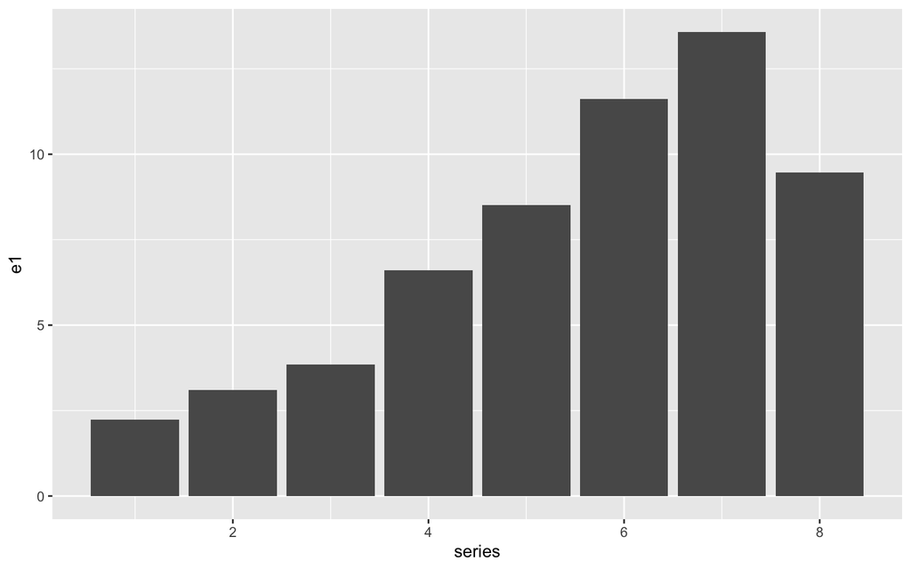

```r
ratings=read.csv("https://raw.githubusercontent.com/ThanhDatIU/datacamp/main/messy_ratings.csv")
# Plot of episode 1 viewers by series
ggplot(ratings, aes(x = series, y = e1)) +
    geom_col()
```

- Adapt your code to make another bar plot just like the first, but this time plot the viewers for the second episode by series.

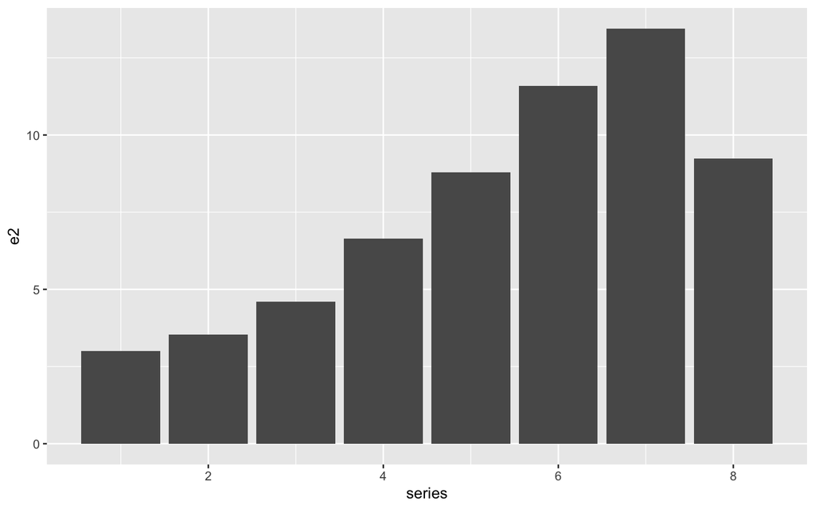

```r
# Adapt code to plot episode 2 viewers by series
ggplot(ratings, aes(x = series, y = e2)) +
    geom_col()
```

Series 8 was the first with different hosts on a different channel. Do you notice a pattern? To draw any conclusions, we’d want to plot the viewers for every episode though- aren’t you glad you weren’t asked to make all 10 plots? Wouldn’t it be nice if episode was a variable we could use?

## 3.2 Gather

### 3.2.1 Gather by hand

Type `mini` in the console to see a small un-tidy data frame. On a sheet of paper, sketch out the tidy version of this data. In the tidy version, what is in the “value” column in the sixth row (not counting the header row)?

IN.

- OUT.
- NA.

Correct! David was IN in episode 2.

### 3.2.2 Gather & plot

In a previous frustrating exercise working with untidy data, we attempted to visualize viewers per episode across series with the untidy `ratings` data.

[figure not shown]

Here is the plot we wanted to create. To make it, we’ll tidy the data, then use [`row_number()`](https://web.archive.org/web/20230309020541/https://www.rdocumentation.org/packages/dplyr/versions/0.7.5/topics/ranking) from the `dplyr` package to create a continuous episode count variable, such that episode 1 from series 1 will have a value of `1`, episode 1 from series 2 will have a value of `7`, and so on. This new variable will be mapped onto the x-axis using `ggplot2`.

- Gather all columns but `series`. Name the key `episode` and the value `viewers_7day`. For plotting, store the key values as a factor variable to preserve the original ordering of the episodes, and remove rows that are `NA`.

```r
tidy_ratings <- ratings %>%
    # Gather and convert episode to factor
    gather(key = "episode", value = "viewers_7day", -series,
           factor_key = TRUE, na.rm = TRUE)
```

- Next, sort the rows by `series` then `episode`.

```r
tidy_ratings <- ratings %>%
    # Gather and convert episode to factor
    gather(key = "episode", value = "viewers_7day", -series,
           factor_key = TRUE, na.rm = TRUE) %>%
    # Sort in ascending order by series and episode
    arrange(series, episode)
```

- Add a line after the `%>%` to create a new cumulative `episode_count` variable using [`row_number()`](https://web.archive.org/web/20230309020541/https://www.rdocumentation.org/packages/dplyr/versions/0.7.5/topics/ranking) from the `dplyr` package.

```r
tidy_ratings <- ratings %>%
    # Gather and convert episode to factor
    gather(key = "episode", value = "viewers_7day", -series,
           factor_key = TRUE, na.rm = TRUE) %>%
    # Sort in ascending order by series and episode
    arrange(series, episode) %>%
    # Create new variable using row_number()
    mutate(episode_count = row_number())
```

- Make a bar chart to visualize 7-day viewers by `episode_count`, filled by `series`.

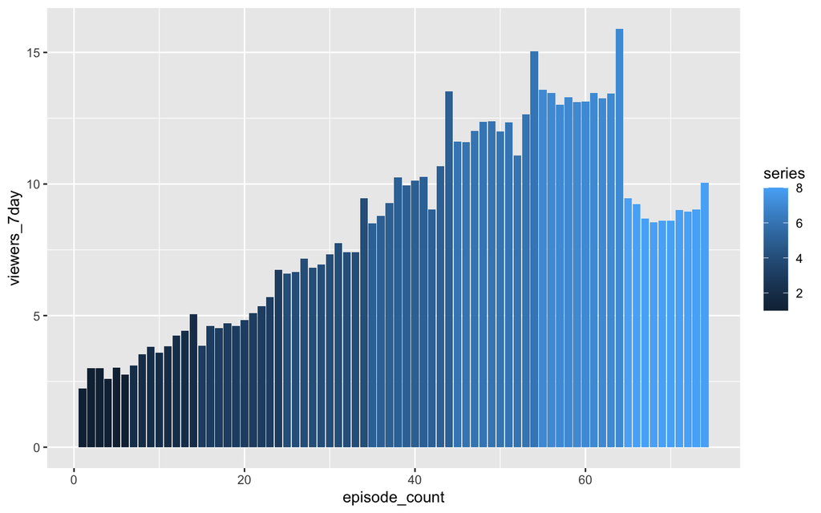

```r
# Plot viewers by episode and series
ggplot(tidy_ratings, aes(x = episode_count,
                         y = viewers_7day,
                         fill = series)) +
    geom_col()
```

Beautiful plot! In series 8, one of the judges accidentally tweeted out the winner’s name 12 hours before the finale aired. Do you think that hurt their finale viewer numbers?

### 3.2.3 Gather & plot non-sequential columns

In this exercise, you’ll combine `tidyr` with [`dplyr::select()`](https://web.archive.org/web/20230309020541/https://www.rdocumentation.org/packages/dplyr/versions/0.7.5/topics/select) to keep and gather non-sequential columns in the `ratings2` data. You can review the `select` [helper functions here](https://web.archive.org/web/20230309020541/https://www.rdocumentation.org/packages/dplyr/versions/0.7.5/topics/select). The `ratings2` data includes per-episode data:

- `e*_7day`: viewers within a 7-day window, and
- `e*_28day`: viewers within a 28-day window.

Here, we’ll focus on the 7-day viewers.

- Create a new data frame called `week_ratings`, selecting the variables you will need from `ratings2` to plot only the 7-day viewers by episode and series.

```r
ratings2=read.csv("https://raw.githubusercontent.com/ThanhDatIU/datacamp/main/messy_ratings2.csv")
# Glimpse new tibble
glimpse(ratings2)
```

```
## Rows: 8
## Columns: 21
## $ series    <int> 1, 2, 3, 4, 5, 6, 7, 8
## $ e1_7day   <dbl> 2.24, 3.10, 3.85, 6.60, 8.51, 11.62, 13.58, 9.46
## $ e1_28day  <dbl> NA, NA, NA, NA, NA, 11.73, 13.86, 9.72
## $ e2_7day   <dbl> 3.00, 3.53, 4.60, 6.65, 8.79, 11.59, 13.45, 9.23
## $ e2_28day  <dbl> NA, NA, NA, NA, NA, 11.84, 13.74, 9.53
## $ e3_7day   <dbl> 3.00, 3.82, 4.53, 7.17, 9.28, 12.01, 13.01, 8.68
## $ e3_28day  <dbl> NA, NA, NA, NA, NA, NA, 13.38, 9.06
## $ e4_7day   <dbl> 2.60, 3.60, 4.71, 6.82, 10.25, 12.36, 13.29, 8.55
## $ e4_28day  <dbl> NA, NA, NA, NA, NA, 12.67, 13.88, 8.87
## $ e5_7day   <dbl> 3.03, 3.83, 4.61, 6.95, 9.95, 12.39, 13.12, 8.61
## $ e5_28day  <dbl> NA, NA, NA, NA, NA, 12.63, 13.33, 8.98
## $ e6_7day   <dbl> 2.75, 4.25, 4.82, 7.32, 10.13, 12.00, 13.13, 8.61
## $ e6_28day  <dbl> NA, NA, NA, NA, NA, 12.26, 13.41, 8.91
## $ e7_7day   <dbl> NA, 4.42, 5.10, 7.76, 10.28, 12.35, 13.45, 9.01
## $ e7_28day  <dbl> NA, NA, NA, NA, NA, 12.58, 13.72, 9.32
## $ e8_7day   <dbl> NA, 5.060, 5.350, 7.410, 9.023, 11.090, 13.260, 8.950
## $ e8_28day  <dbl> NA, NA, NA, NA, NA, 11.35, 13.45, 9.19
## $ e9_7day   <dbl> NA, NA, 5.70, 7.41, 10.67, 12.65, 13.44, 9.03
## $ e9_28day  <dbl> NA, NA, NA, NA, NA, 12.78, 13.65, 9.16
## $ e10_7day  <dbl> NA, NA, 6.74, 9.45, 13.51, 15.05, 15.90, 10.04
## $ e10_28day <dbl> NA, NA, NA, NA, NA, 15.16, 16.03, 10.13
```

```r
# Select 7-day viewer ratings
week_ratings <- ratings2 %>%
    select(series, ends_with("7day"))
```

- Add a line after the `%>%` to gather the 7-day viewer data into one column called `viewers_7day`, removing all rows with missing values and converting the key variable, `episode`, to a factor.

```r
week_ratings <- ratings2 %>%
    # Select 7-day viewer ratings
    select(series, ends_with("7day")) %>%
    # Gather 7-day viewers by episode
    gather(episode, viewers_7day, ends_with("7day"), na.rm = TRUE, factor_key = TRUE)
```

- Make a line plot to visualize the 7-day viewers by `episode`, facetted by `series`. Since the x-axis is a factor, you’ll use the group aesthetic to plot one line per `series`.

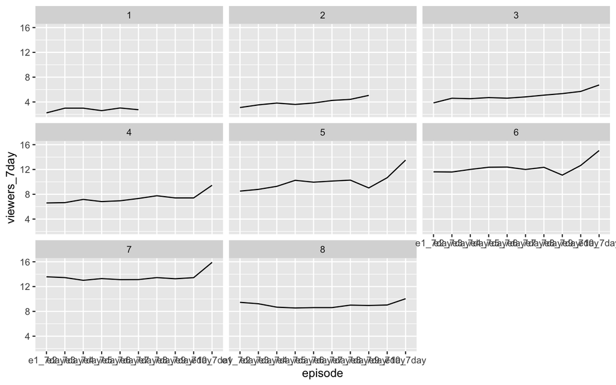

```r
# Plot 7-day viewers by episode and series
ggplot(week_ratings, aes(x = episode,
                         y = viewers_7day,
                         group = series)) +
    geom_line() +
    facet_wrap(~series)
```

You’re done gathering! This plot tells you a lot, but the x-axis labels are a mess! We need to do more tidying to make this plot better.

## 3.3 separate()

### 3.3.1 Separate a column

To create the `week_ratings` data, we first selected all the columns in `ratings2` that contain data about the number of 7-day viewers in millions for each series, then we gathered those 10 columns into two columns.

In this exercise, you’ll use the `tidyr`, `dplyr`, and `readr` packages (all are loaded) to tidy and plot the `week_ratings` data so we can read the x-axis, which labels each episode!

Add a line after the `%>%` in your code from the last set of gathering exercises to separate the existing column named `episode` into a new column also called `episode`.

Drop the extra part that always says “7day”.

```r
week_ratings <- ratings2 %>%
    select(series, ends_with("7day")) %>%
    gather(episode, viewers_7day, ends_with("7day"),
           na.rm = TRUE) %>%
    # Edit to separate key column and drop extra
    separate(episode, into = "episode", extra = "drop")
```

Print to view the result.

```r
# Print to view
week_ratings
```

```
##    series episode viewers_7day
## 1       1      e1        2.240
## 2       2      e1        3.100
## 3       3      e1        3.850
## 4       4      e1        6.600
## 5       5      e1        8.510
## 6       6      e1       11.620
## 7       7      e1       13.580
## 8       8      e1        9.460
## 9       1      e2        3.000
## 10      2      e2        3.530
## 11      3      e2        4.600
## 12      4      e2        6.650
## 13      5      e2        8.790
## 14      6      e2       11.590
```

[output cut: 60 more lines]

- The `episode` column is a character, but it will be easier to work with as a number. Use `readr::parse_number()` to drop the non-numeric characters before the episode number. Print again to view.

```r
week_ratings <- ratings2 %>%
    select(series, ends_with("7day")) %>%
    gather(episode, viewers_7day, ends_with("7day"),
           na.rm = TRUE) %>%
    separate(episode, into = "episode", extra = "drop") %>%
    # Edit to parse episode number
    mutate(episode = parse_number(episode))

# Print to view
week_ratings
```

```
##    series episode viewers_7day
## 1       1       1        2.240
## 2       2       1        3.100
## 3       3       1        3.850
## 4       4       1        6.600
## 5       5       1        8.510
## 6       6       1       11.620
## 7       7       1       13.580
## 8       8       1        9.460
## 9       1       2        3.000
## 10      2       2        3.530
## 11      3       2        4.600
## 12      4       2        6.650
## 13      5       2        8.790
## 14      6       2       11.590
```

[output cut: 60 more lines]

- Edit your code for the facetted line plot from the previous exercise to also color the lines by `series`. Using [`guides()`](https://web.archive.org/web/20230309020541/https://www.rdocumentation.org/packages/ggplot2/versions/3.0.0/topics/guides), remove the `color` guide by setting it equal to `FALSE`, and add `theme_minimal()`.

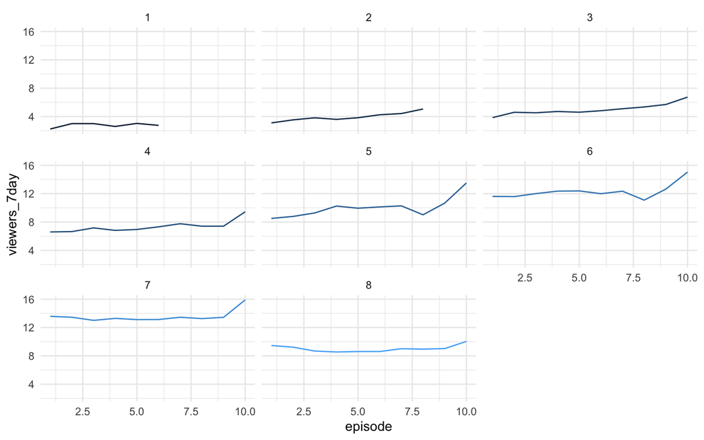

```r
# Edit your code to color by series and add a theme
ggplot(week_ratings, aes(x = episode, y = viewers_7day,
                         group = series, color = series)) +
    geom_line() +
    facet_wrap(~series) +
    guides(color = FALSE) +
    theme_minimal()
```

Nice work separating and parsing- you are becoming a tidy data pro! Notice the x-axis in this plot: episodes don’t actually have decimals! We’ll see how to deal with this in the last chapter when we work with factors.

### 3.3.2 Unite columns

In the `tidyr` package, the opposite of `separate()` is [`unite()`](https://web.archive.org/web/20230309020541/https://www.rdocumentation.org/packages/tidyr/versions/0.8.1/topics/unite). Sometimes you need to paste values from two or more columns together to tidy. Here is an example usage for `unite()`:

```
data %>%
    unite(new_var, old_var1, old_var2)
```

The `ratings2` dataset includes these variables:

- `series`: 1-8
- `episode`: 1-10
- `viewers_millions`: whole number of 7-day viewers in millions
- `viewers_decimal`: additional number of 7-days viewers in millions

- Create a new variable by uniting the two viewers data columns into one column called `viewers_7day`; print to view.

```r
ratings_2=read.csv("https://raw.githubusercontent.com/ThanhDatIU/datacamp/main/rating_s2.csv")
ratings3 <- ratings_2  %>%
    # Unite viewers in millions and decimals together
    unite(viewers_7day, viewers_millions, viewers_decimal)

# Print to view
ratings3
```

```
##    series episode viewers_7day
## 1       1       1       2_0.24
## 2       1       2         3_NA
## 3       1       3         3_NA
## 4       1       4        2_0.6
## 5       1       5       3_0.03
## 6       1       6       2_0.75
## 7       2       1        3_0.1
## 8       2       2       3_0.53
## 9       2       3       3_0.82
## 10      2       4        3_0.6
## 11      2       5       3_0.83
## 12      2       6       4_0.25
## 13      2       7       4_0.42
## 14      2       8       5_0.06
```

[output cut: 60 more lines]

- Adapt your `unite()` code to use a new argument, `sep`. The default separator between new columns is `_`. Instead, set `sep = ““`. Print the new data frame to view it.

```r
ratings3 <- ratings_2  %>%
    # Adapt to change the separator
    unite(viewers_7day, viewers_millions, viewers_decimal, sep = "")

# Print to view
ratings3
```

```
##    series episode viewers_7day
## 1       1       1        20.24
## 2       1       2          3NA
## 3       1       3          3NA
## 4       1       4         20.6
## 5       1       5        30.03
## 6       1       6        20.75
## 7       2       1         30.1
## 8       2       2        30.53
## 9       2       3        30.82
## 10      2       4         30.6
## 11      2       5        30.83
## 12      2       6        40.25
## 13      2       7        40.42
## 14      2       8        50.06
```

[output cut: 60 more lines]

- Adapt the provided code to cast the new `viewers_7day` column to a number.

```r
ratings3 <- ratings_2  %>%
    # Unite and change the separator
    unite(viewers_7day, viewers_millions, viewers_decimal, sep = "") %>%
    # Adapt to cast viewers as a number
    mutate(viewers_7day = parse_number(viewers_7day))

# Print to view
ratings3
```

```
##    series episode viewers_7day
## 1       1       1        20.24
## 2       1       2         3.00
## 3       1       3         3.00
## 4       1       4        20.60
## 5       1       5        30.03
## 6       1       6        20.75
## 7       2       1        30.10
## 8       2       2        30.53
## 9       2       3        30.82
## 10      2       4        30.60
## 11      2       5        30.83
## 12      2       6        40.25
## 13      2       7        40.42
## 14      2       8        50.06
```

[output cut: 60 more lines]

Good Job!

## 3.4 spread()

### **Spread rows into columns**

In this exercise, you’ll use the `tidyr`, `dplyr`, and `readr` packages to tidy the `ratings2` data after using `dplyr::count()`. The `tidy_ratings_all` data should have four variables to work with:

- `series` (integer: 1-8),
- `episode` (integer: 1-10),
- `days` (integer: 7 or 28), and
- `viewers` (numeric).
- Start by gathering all columns that end with “day” into two columns: `episode` and `viewers`. Separate the key column into two columns named `episode` and `days`. Both of these two separated columns need to be parsed as numbers also, within a `mutate`.

```r
# Create tidy data with 7- and 28-day viewers
tidy_ratings_all <- ratings_2 %>%
    gather(key = episode, value = viewers, ends_with("day"), na.rm = TRUE) %>%
    separate(episode, into = c("episode", "days")) %>%
    mutate(episode = parse_number(episode),
           days = parse_number(days))
```

- Using your new tidy data, count the number of viewers grouping by `series` and `days`. **Remember:** you *don’t* need to use `group_by` before `count`, but you *do* need to use the `wt =` argument to sum the values in the `viewers` column.

```r
# Create tidy data with 7- and 28-day viewers
tidy_ratings_all <- ratings2 %>%
    gather(episode, viewers, ends_with("day"), na.rm = TRUE) %>%
    separate(episode, into = c("episode", "days")) %>%
    mutate(episode = parse_number(episode),
           days = parse_number(days))

tidy_ratings_all %>%
    # Count viewers by series and days
    count(series, days, wt = viewers)
```

```
##    series days       n
## 1       1    7  16.620
## 2       2    7  31.610
## 3       3    7  50.010
## 4       4    7  73.540
## 5       5    7 100.393
## 6       6    7 123.110
## 7       6   28 113.000
## 8       7    7 135.630
## 9       7   28 138.450
## 10      8    7  90.170
## 11      8   28  92.870
```

- Add a line after the `%>%` to reshape the output of `count` such that you have 3 columns: `series`, `days_7`, and `days_28`. To do this within [`spread()`](https://web.archive.org/web/20230309020541/https://www.rdocumentation.org/packages/tidyr/versions/0.8.1/topics/spread), set `sep = “_“` as an argument.

```r
# Create tidy data with 7- and 28-day viewers
tidy_ratings_all <- ratings2 %>%
    gather(episode, viewers, ends_with("day"), na.rm = TRUE) %>%
    separate(episode, into = c("episode", "days")) %>%
    mutate(episode = parse_number(episode),
           days = parse_number(days))

tidy_ratings_all %>%
    # Count viewers by series and days
    count(series, days, wt = viewers) %>%
    # Adapt to spread counted values
    spread(days, n, sep = "_")
```

```
##   series  days_7 days_28
## 1      1  16.620      NA
## 2      2  31.610      NA
## 3      3  50.010      NA
## 4      4  73.540      NA
## 5      5 100.393      NA
## 6      6 123.110  113.00
## 7      7 135.630  138.45
## 8      8  90.170   92.87
```

Great work! The `sep = “_“` argument is especially helpful when you are spreading by a numeric variable so that you don’t end up with variable names that start with numbers.

## 3.5 Tidy multiple sets of columns

### 3.5.1 Masterclass: Tidy I

In the last three exercises, you’ll tidy the `ratings` data to create a scatterplot to see the relationship between the number of premiere and finale UK viewers (7-day only) by series.

- Create a new tibble called `tidy_ratings` by gathering the 7-day viewer data by `episode` (all columns except `series`), removing the rows from output where the value column in `NA`. The key column should be named `episode`, the value should be `viewers`.

```r
# Gather viewer columns and remove NA rows
tidy_ratings <- ratings %>%
    gather(key = episode, value = viewers, -series, na.rm = TRUE)
```

Using the pipe, add a line of code to convert the `episode` variable into a number.

```r
# Adapt code to parse episode as a number
tidy_ratings <- ratings %>%
    gather(episode, viewers, -series, na.rm = TRUE) %>%
    mutate(episode = parse_number(episode))
```

Fill in the blanks in the provided code to filter rows that contain viewer data for each series’ premiere and finale episodes- don’t forget to undo the grouping when you are done!

```r
# Fill in blanks to get premiere/finale data
tidy_ratings <- ratings %>%
    gather(episode, viewers, -series, na.rm = TRUE) %>%
    mutate(episode = parse_number(episode)) %>%
    group_by(series) %>%
    filter(episode == 1 | episode == max(episode)) %>%
    ungroup()
```

Now we have a tidy version of the `ratings` data with only premiere and finale episodes. Let’s see if that tweet spoiled the Series 8 finale. You’ll see why we needed the last `ungroup()` in the next exercises.

### 3.5.2 Masterclass: Tidy II

In the previous exercise, you gathered, then did a grouped filter to make `tidy_ratings`. In this exercise, you’ll make two charts in `ggplot2` with this tidy data to see if the judge’s tweet spoiled the Series 8 finale ratings.

The two plots you’ll make, a slope chart and a dumbbell chart, are nice ways to show change between two data points combining `geom_point()` and `geom_line()`.

You’ll use these to visualize the “finale bump” in viewers between the premiere and finale episodes across series.

Recode the `episode` variable as either `“first”` or `“last”`.

```r
# Recode first/last episodes
first_last <- tidy_ratings %>%
  mutate(episode = recode(episode, `1` = "first", .default = "last"))
```

Make a slope chart where the x-axis values are either `“first”` or `“last”`, and the slope of the line connecting the two points shows the change in viewers. Color the points and lines by `series`.

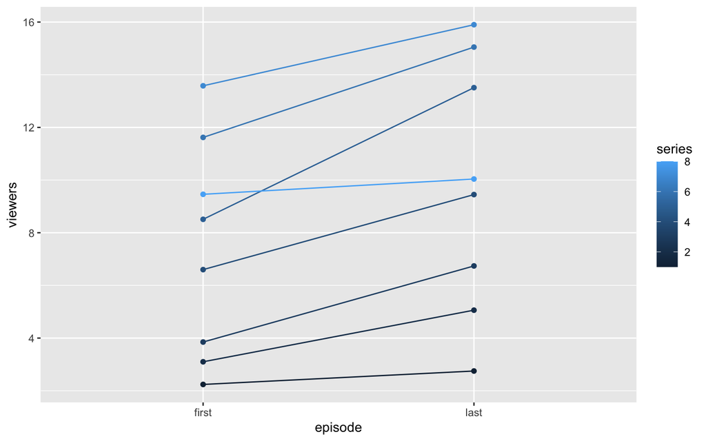

```r
# Fill in to make slope chart
ggplot(first_last, aes(x = episode, y = viewers, color = series)) +
  geom_point() +
  geom_line(aes(group = series))
```

To make a dumbbell chart instead, switch the x-axis and color variable mapping. After flipping the axes using `coord_flip()`, the length of the “dumbbell” now illustrates the size of the “finale bump.”

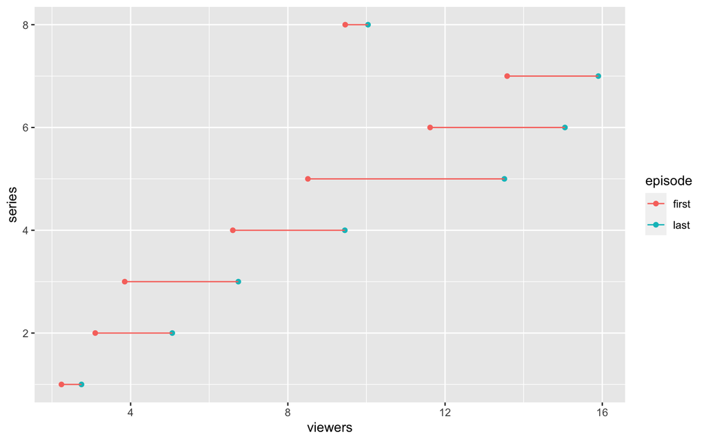

```r
# Switch the variables mapping x-axis and color
ggplot(first_last, aes(x = series, y = viewers, color = episode)) +
  geom_point() + # keep
  geom_line(aes(group = series)) + # keep
  coord_flip() # keep
```

Great work- notice how each of these two plots relied on data that is tidy! Series 8 had a pretty small ‘finale bump’, but we are still looking at raw changes in viewers. Let’s visualize percentage changes in viewers instead.

### 3.5.3 Masterclass: Tidy III

In the previous exercise, you visualized the size of the “finale bump” in viewers for each series. From those charts, we know that finale episodes always garner more viewers than premieres. We also know that the change in viewers for series 8 seemed smaller compared to some previous series.

But the question of whether the series 8 finale viewers were “spoiled” might be best answered by comparing the relative percentage changes in premiere and finale viewers across series. In this exercise, you’ll reshape `first_last` once more to calculate and visualize the *relative finale bump*.

Create a new data frame called `bump_by_series` with three columns: `series`, `first`, and `last`.

```r
# Spread into three columns
bump_by_series <- first_last %>%
    spread(episode, viewers)
```

Add a line after the `%>%` to create a new variable called `bump` to calculate the difference between finale and premiere viewers in the numerator, divided by the number of premiere viewers.

```r
# Calculate relative increase in viewers
bump_by_series <- first_last %>%
    spread(episode, viewers) %>%
    mutate(bump = (last - first) / first)
```

Fill in the provided code to make a bar chart with one bar per series, where the height of the bar shows the bump in 7-day viewers from the premiere to the finale episodes. Do any series stand out?

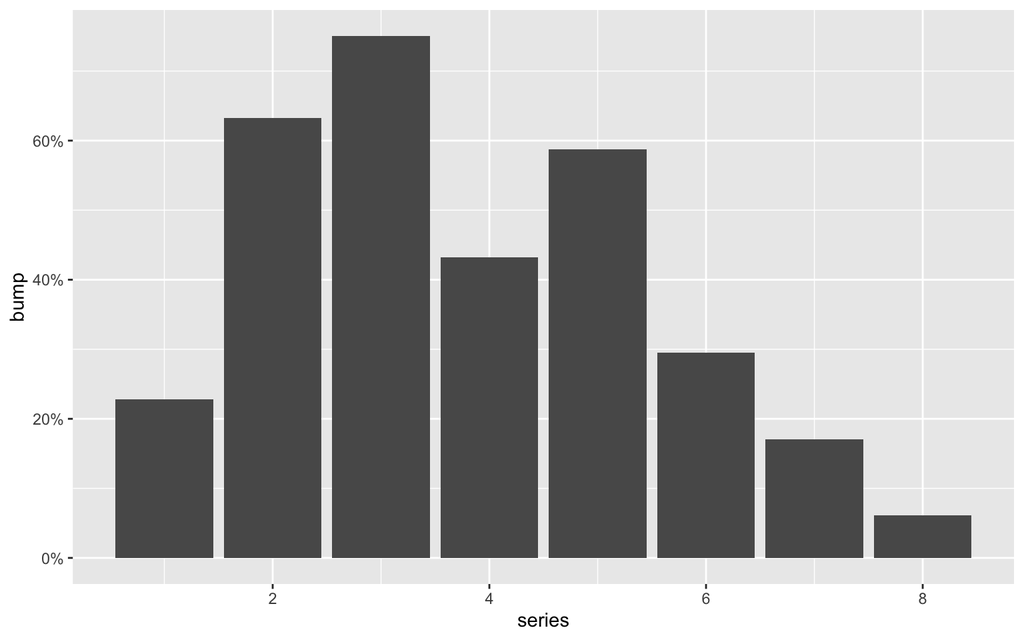

```r
# Fill in to make bar chart of bumps by series
ggplot(bump_by_series, aes(x = series, y = bump)) +
  geom_col() +
  scale_y_continuous(labels = scales::percent) # converts to %
```

Series 8 definitely had the lowest ‘finale bump’ so far- only 6% more viewers watched the finale than the premiere. Notice that we had to `spread` here, because the tidy version of the data depends on the question you want to ask.

# 4 Transform your data

In this chapter, you will learn how to tame specific types of variables that are known to be tricky to work with, such as dates, strings, and factors.

## 4.1 Recoding with case_when

### 4.1.1 Combine two variables

In this exercise, you’ll use `case_when()` with the `bakers` data to create a new variable based on the number of times each baker was crowned as star baker or the technical challenge winner:

- If star baker is *greater than* technical wins, recode as `super_star`
- If star baker is *less than* technical wins, recode as `high_tech`
- Recode the rest as `well_rounded`

Create a new variable with three levels as described above.

```r
bakers=read.csv("https://raw.githubusercontent.com/ThanhDatIU/datacamp/main/baker_results.csv")
# Create skills variable with 3 levels
bakers_skill <- bakers %>%
  mutate(skill = case_when(
    star_baker > technical_winner ~ "super_star",
    star_baker < technical_winner ~ "high_tech",
    TRUE ~ "well_rounded"
  ))
```

Filter the rows where both `star_baker` and `technical_winner` are zero, then count the number of bakers by `skill`. How many do you see?

```r
# Filter zeroes to examine skill variable
bakers_skill %>%
  filter(star_baker == 0 & technical_winner == 0) %>%
  count(skill)
```

```
##          skill  n
## 1 well_rounded 41
```

Whoops- we may not want bakers who never won star baker or the technical challenge to be called ‘well-rounded’. Let’s add another level to take care of this!

### 4.1.2 Add another bin

In this exercise, you’ll edit your previous code so that `skill` has four levels:

- If both star baker and technical wins are zero, recode as `NA_character_`
- If star baker is *greater than* technical wins, recode as `super_star`
- If star baker is *less than* technical wins, recode as `high_tech`
- If star baker is *equal to* technical wins, recode as `well_rounded`

Edit the `skill` variable you just created to have the four levels as described above.

```r
# Edit skill variable to have 4 levels
bakers_skill <- bakers %>%
  mutate(skill = case_when(
    star_baker > technical_winner ~ "super_star",
    star_baker < technical_winner ~ "high_tech",
    star_baker == 0 & technical_winner == 0 ~ NA_character_,
    star_baker == technical_winner  ~ "well_rounded"
  ))
```

Add a pipe and use [`drop_na()`](https://web.archive.org/web/20230309020541/https://www.rdocumentation.org/packages/tidyr/versions/0.8.1/topics/drop_na) from the `tidyr` package to drop all rows where `skill` is `NA`.

```r
# Add pipe to drop skill = NA
bakers_skill <- bakers %>%
  mutate(skill = case_when(
    star_baker > technical_winner ~ "super_star",
    star_baker < technical_winner ~ "high_tech",
    star_baker == 0 & technical_winner == 0 ~ NA_character_,
    star_baker == technical_winner  ~ "well_rounded"
  )) %>%
  drop_na(skill)
```

Count the number of bakers in each `skill` level.

```r
# Count bakers by skill
bakers_skill %>%
  count(skill)
```

```
##          skill  n
## 1    high_tech 24
## 2   super_star 15
## 3 well_rounded 15
```

Very nice- now we only have 15 ‘well-rounded’ bakers, and we dropped the 41 bakers who never won star baker or a technical challenge.

## 4.2 Factors

### 4.2.1 Cast a factor and examine levels

In this exercise, you’ll start where you left off in the last series of exercises, working with the `bakers` data to examine your new categorical variable called `skill`, which has three levels: `well_rounded`, `super_star`, and `high_tech`.

Cast the `skill` variable as a factor.

```r
bakers=bakers_skill
# Cast skill as a factor
bakers <- bakers %>%
  mutate(skill = as.factor(skill))
```

Examine the levels of the factor, and if you were to plot it, think about what the order of the levels would be.

```r
# Examine levels
bakers %>%
  pull(skill) %>%
  levels()
```

```
## [1] "high_tech"    "super_star"   "well_rounded"
```

Sometimes factors have a natural order to them- like beginner, intermediate, and advanced- but sometimes they don’t. Know your data, and know your factors!

### 4.2.2 Plot factor counts

In this exercise, you’ll use `ggplot2` to make a bar chart with one per level of the `skill` factor we just made, where the height of the bar shows the number of bakers in each skill level.

Notice a *big* difference between the data here and the data we have used before to make a bar chart- here, you want the height of the bars to be represent the number of rows in the `bakers` data in each skill level. This is compared to bar charts we made where the height represented values in the data (when you used `geom_col()`).

[figure not shown]

```r
# Plot counts of bakers by skill, fill by winner
ggplot(bakers, aes(x = skill, fill = series_winner)) +
  geom_bar()
```

Edit your plot code to reverse the order of the `skill` factor levels along the x-axis.

[figure not shown]

```r
# Edit to reverse x-axis order
ggplot(bakers, aes(x = fct_rev(skill), fill = series_winner)) +
  geom_bar()
```

Great job! Note that when you use function like `fct_rev()`, `forcats` converts the character to a factor for your plot only.

## 4.3 Dates

### 4.3.1 Cast characters as dates

As we saw in the video, you can use `lubridate` to parse and cast a date variable within a `mutate()`. In this exercise, you’ll practice doing this with the `baker_dates` data, and then go even further to extract data from the dates like the labelled month. Remember to use `?month` to read about the `month()` function and its arguments.

Cast `last_date_appeared_us` as a date.

```r
library(lubridate)
baker_dates=read.csv("https://raw.githubusercontent.com/ThanhDatIU/datacamp/main/baker_dates.csv")
# Cast last_date_appeared_us as a date
baker_dates_cast <- baker_dates %>%
  mutate(last_date_appeared_us = dmy(last_date_appeared_us))
```

Add a line to your code to create a new variable called `last_month_us`, with the month of each bakers’ last date appeared in the US as a character string such as “Jan.”

```r
library(lubridate)
# Add a line to extract labeled month
baker_dates_cast <- baker_dates %>%
  mutate(last_month_us = month(last_date_appeared_us, label = TRUE))
```

Use a bar chart to plot the frequencies of bakers by `last_month_us`- in which month have we said goodbye to the most bakers?

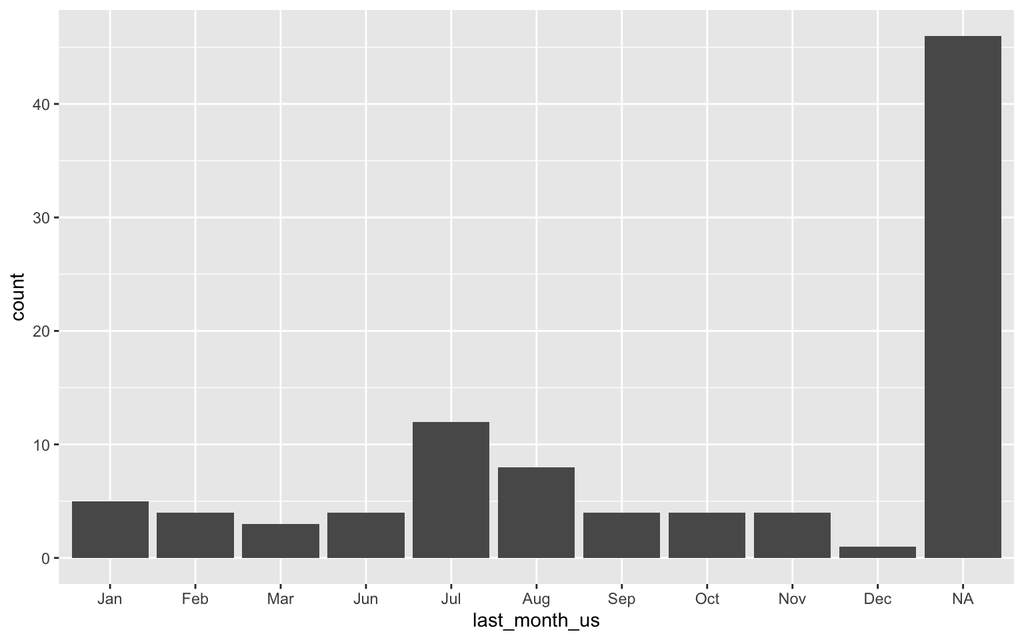

```r
# Make bar chart by last month
ggplot(baker_dates_cast, aes(x = last_month_us)) +
    geom_bar()
```

Success! There are more functions like `year` for getting out other date components- you can even extract fiscal quarters or semesters! Look at the documentation to see more ways.

### 4.3.2 Calculate timespans

As we saw in the video, the first step to calculating a timespan in `lubridate` is to make an `interval`, then use division to convert the units to what you want (like `weeks(x)` or `months(x)`). The `x` refers to the number of time units to be included in the period. In this exercise, you’ll calculate timespans with the `baker_time` data we just made.

- Create a new `interval` called `time_on_air`, calculated as the timespan between each baker’s first and last date that they appeared in the UK.

```r
baker_time <- baker_dates  %>%
  mutate(time_on_air = interval(first_date_appeared_uk, last_date_appeared_uk),
         weeks_on_air = time_on_air / weeks(1),
         months_on_air = time_on_air %/% months(1))

# Create interval between first and last UK dates
baker_time <- baker_time %>%
  mutate(time_on_air = interval(first_date_appeared_uk, last_date_appeared_uk))
```

- Add another line to your `mutate()` call to create another variable called `weeks_on_air`, which converts `time_on_air` to the number of weeks (time unit = 1).

```r
# Add a line to create weeks on air variable
baker_time <- baker_time  %>%
  mutate(time_on_air = interval(first_date_appeared_uk, last_date_appeared_uk),
         weeks_on_air = time_on_air / weeks(1))
```

- Add another line to your `mutate()` call to create another variable called `months_on_air`, which stores the number of months each baker was “on air” in whole numbers.

```r
# Add a line to create whole months on air variable
baker_time <- baker_time  %>%
  mutate(time_on_air = interval(first_date_appeared_uk, last_date_appeared_uk),
         weeks_on_air = time_on_air / weeks(1),
         months_on_air = time_on_air %/% months(1))
```

Here again, `lubridate` gives you many options for working with periods from `years` down to `picoseconds`. You may also end up needing to work with durations too, which have similar functions that always start with a `d` from `dyears` to `dpicoseconds`.

## 4.4 Strings

### 4.4.1 Wrangle a character variable

In this exercise, we’ll wrangle the values in the `position_reached` variable, which looks like this right now:

```
bakers %>%
  count(position_reached)
# A tibble: 8 x 2
  position_reached     n
  <chr>            <int>
1 Runner up            2
2 Runner Up           12
3 Runner-Up            1
4 Third Place          1
5 winner               2
6 Winner               1
7 WINNER               5
8 NA                  71
```

Let’s clean these strings up!

Convert all the values in the `position_reached` variable to upper case.

```r
bakers=read.csv("https://raw.githubusercontent.com/ThanhDatIU/datacamp/main/messy_baker_results.csv")
# Convert to lower case
bakers <- bakers %>%
  mutate(position_reached = str_to_upper(position_reached))
```

Replace all dashes with a single space (`” “`).

```r
# Add another mutate to replace "-" with " "
bakers <- bakers %>%
  mutate(position_reached = str_to_upper(position_reached),
         position_reached = str_replace(position_reached, "-", " "))
```

Replace “THIRD PLACE” with “RUNNER UP”, and count your new `position_reached` variable.

```r
# Add another mutate to replace "THIRD PLACE" with "RUNNER UP" and count
bakers <- bakers %>%
  mutate(position_reached = str_to_upper(position_reached),
         position_reached = str_replace(position_reached, "-", " "),
         position_reached = str_replace(position_reached, "THIRD PLACE", "RUNNER UP"))

# Count rows
bakers %>%
  count(position_reached)
```

```
##   position_reached  n
## 1        RUNNER UP 16
## 2           WINNER  8
## 3             <NA> 71
```

Great work! Each of the 8 series had one winner and two runner-ups, so now this variable is much easier to work with!

### 4.4.2 Detect a string pattern

In this exercise, we’ll wrangle each bakers’ `occupation` from the `bakers` data, which is currently a character string like this:

```
bakers %>%
  select(baker, occupation)
# A tibble: 6 x 2
  baker   occupation
  <chr>   <chr>
1 Jason   Civil Engineering Student
2 Simon   Rugby Coach
3 Enwezor Business consultant
4 Martha  Student
5 Lee     Pastor
6 Liam    Student
```

We’ll create a logical variable (`TRUE` or `FALSE`) indicating whether or not each baker is a student.

Convert all the values in the `occupation` variable to lower case.

```r
# Convert to lower case
bakers <- bakers %>%
    mutate(occupation = str_to_lower(occupation))
```

Create a new variable called `student` that is `TRUE` if the string `“student”` is present in the `occupation` variable, and `FALSE` if it is not.

```r
# Add a line to create new variable called student
bakers <- bakers %>%
    mutate(occupation = str_to_lower(occupation),
           student = str_detect(occupation, "student"))
```

Filter all students in the `bakers` data frame, and look at their names, occupations, and confirm that they are all students. Did we mis-classify anyone?

```r
# Find all students and examine occupations
bakers %>%
  filter(student == TRUE) %>%
  select(baker, occupation, student)
```

```
##     baker                            occupation student
## 1   Jason             civil engineering student    TRUE
## 2   James                       medical student    TRUE
## 3    John                           law student    TRUE
## 4    Ruby history of art and philosophy student    TRUE
## 5  Martha                               student    TRUE
## 6 Michael                               student    TRUE
## 7     Rav                       student support    TRUE
## 8    Liam                               student    TRUE
```

Rav’s occupation was student support, but we classified him as a student. This shows a common problem in working with data- it helps to always check your work!